# Analisi dades

Laura Guzman

16 d’agost de 2019

```r
library(ggplot2)
library(timeDate)
library(lubridate)
library(gdata)
library(knitr)
```

**Negreta** *Cursiva*

# Arxiu informations_households

```r
#Carreguem arxiu de dades
informations_households <-read.csv(file="dades/1informations_households.csv", header=TRUE, sep=",", stringsAsFactors = FALSE)
```

```r
# Tipus de dades
print("Tipus de dades")
```

```
## [1] "Tipus de dades"
```

```r
str(informations_households)
```

```
## 'data.frame':    5566 obs. of  5 variables:
##  $ LCLid        : chr  "MAC005492" "MAC001074" "MAC000002" "MAC003613" ...
##  $ stdorToU     : chr  "ToU" "ToU" "Std" "Std" ...
##  $ Acorn        : chr  "ACORN-" "ACORN-" "ACORN-A" "ACORN-A" ...
##  $ Acorn_grouped: chr  "ACORN-" "ACORN-" "Affluent" "Affluent" ...
##  $ file         : chr  "block_0" "block_0" "block_0" "block_0" ...
```

```r
# Per a quines variables tindria sentit un proc?s de discretitzaci??
apply(informations_households,2, function(x) length(unique(x)))
```

```
##         LCLid      stdorToU         Acorn Acorn_grouped          file
##          5566             2            19             5           112
```

```r
#Convertim stdorToU, Acorn , Acorn_grouped i file en factors

informations_households$stdorToU<-as.factor(informations_households$stdorToU)
informations_households$Acorn<-as.factor(informations_households$Acorn)
informations_households$Acorn_grouped<-as.factor(informations_households$Acorn_grouped)
informations_households$file<-as.factor(informations_households$file)
```

```r
# Comprovem
print("Tipus de dades")
```

```
## [1] "Tipus de dades"
```

```r
str(informations_households)
```

```
## 'data.frame':    5566 obs. of  5 variables:
##  $ LCLid        : chr  "MAC005492" "MAC001074" "MAC000002" "MAC003613" ...
##  $ stdorToU     : Factor w/ 2 levels "Std","ToU": 2 2 1 1 1 1 1 1 1 1 ...
##  $ Acorn        : Factor w/ 19 levels "ACORN-","ACORN-A",..: 1 1 2 2 2 2 2 2 2 2 ...
##  $ Acorn_grouped: Factor w/ 5 levels "ACORN-","ACORN-U",..: 1 1 4 4 4 4 4 4 4 4 ...
##  $ file         : Factor w/ 112 levels "block_0","block_1",..: 1 1 1 1 1 1 1 1 1 1 ...
```

```r
#Resum dades

#Dimensió
print("Dimensió")
```

```
## [1] "Dimensió"
```

```r
dim(informations_households)
```

```
## [1] 5566    5
```

```r
# Resum
print("Resum estad?stic")
```

```
## [1] "Resum estad?stic"
```

```r
summary(informations_households)
```

```
##     LCLid           stdorToU       Acorn          Acorn_grouped
##  Length:5566        Std:4443   ACORN-E:1567   ACORN-     :   2
##  Class :character   ToU:1123   ACORN-Q: 831   ACORN-U    :  49
##  Mode  :character              ACORN-F: 684   Adversity  :1816
##                                ACORN-H: 455   Affluent   :2192
##                                ACORN-L: 342   Comfortable:1507
##                                ACORN-D: 292
##                                (Other):1395
##         file
##  block_0  :  50
##  block_1  :  50
##  block_10 :  50
##  block_100:  50
##  block_101:  50
##  block_102:  50
##  (Other)  :5266
```

```r
#Mostrem tots els grups d'Acorn
print("Resum grups Acorn")
```

```
## [1] "Resum grups Acorn"
```

```r
summary(informations_households$Acorn)
```

```
##  ACORN- ACORN-A ACORN-B ACORN-C ACORN-D ACORN-E ACORN-F ACORN-G ACORN-H
##       2     157      25     151     292    1567     684     205     455
## ACORN-I ACORN-J ACORN-K ACORN-L ACORN-M ACORN-N ACORN-O ACORN-P ACORN-Q
##      51     112     165     342     113     152     103     110     831
## ACORN-U
##      49
```

```r
options(knitr.kable.NA = '')
kable(summary(informations_households),
digits=2, align='l', caption="Estadística descriptiva")
```

Estadística descriptiva

|  | LCLid | stdorToU | Acorn | Acorn_grouped | file |
| --- | --- | --- | --- | --- | --- |
|  | Length:5566 | Std:4443 | ACORN-E:1567 | ACORN- : 2 | block_0 : 50 |
|  | Class :character | ToU:1123 | ACORN-Q: 831 | ACORN-U : 49 | block_1 : 50 |
|  | Mode :character |  | ACORN-F: 684 | Adversity :1816 | block_10 : 50 |
|  |  |  | ACORN-H: 455 | Affluent :2192 | block_100: 50 |
|  |  |  | ACORN-L: 342 | Comfortable:1507 | block_101: 50 |
|  |  |  | ACORN-D: 292 |  | block_102: 50 |
|  |  |  | (Other):1395 |  | (Other) :5266 |

Veiem que tenim 5566 files amb 5 columnes. Les columnes s?n les seg?ents variables:

LCLid: Id de la llar. stdorTou: Tipus de tarifa. Acorn: Acorn associat. Acorn_grouped: Detalls de l’acorn. file: Nom del fitxer al que trobar les dades d’energia.

On cada fila representa una llar. Observem que tenim 5566 llars, on 4443 tenen tarifa “Std” i 1123 tenen tarifa “ToU” (Dynamic Time of Use). En la tarifa dTou, els preus de la tarifa es d?nen el dia abans a trav?s de l’Smart Meter IHD (In Home Display) o a trav?s d’un missatge al m?vil. Amb aquesta tarifa es tenen 3 preus segons l’horari, que s?n: alt=67.20p/kWh, normal=11.76p/kWh i baix=3.99p/kWh. **Es podria estudiar com afecta aquest preu al consum horari d’aquests clients. Els clients que no tenen aquesta tarifa, non-Time of Use(std), tenen una tarifa plana de 14.228p/kWh.

Veiem que els grups Acorn comprenen des de ACORN-, ACORN-A, ACORN-B … fins ACORN-U (19 grups) i que la variable Acorn_grouped t? 5 atributs(ACORN-, ACORN-U, Adversity, Affluent i Comfortable), on Affluent ?s el que apareix m?s vegades.

De la variable file, sabem que tenim 112 blocs, des del block_0 al block_111.

Ens adonem que ACORN-U i ACORN- de Acorn_grouped han de ser errors, ja que en la descripció de les dades original ens diuen que tenim 3 tipus d’Acorn_grouped, de manera que els hem de re-classificar dins d’una de les 3 classes. En l’estudi realitzat per l’autor de les dades a Kaggle, comenta que les llars de la mateixa ACORN estan en la mateixa fila. Amb aquestes dades, estudiem la relació que hi ha entre Acorn, Acorn_grouped i file per poder re-classificar els valors amb errors. També ha de ser un error el valor ACORN- de la variable Acorn, ja que tant sols hi ha 2 llars d’aquest tipus.

```r
#Acorn-Acorn grouped

#Taula freq??ncies
table(informations_households$Acorn,informations_households$Acorn_grouped)
```

```
##
##           ACORN- ACORN-U Adversity Affluent Comfortable
##   ACORN-       2       0         0        0           0
##   ACORN-A      0       0         0      157           0
##   ACORN-B      0       0         0       25           0
##   ACORN-C      0       0         0      151           0
##   ACORN-D      0       0         0      292           0
##   ACORN-E      0       0         0     1567           0
##   ACORN-F      0       0         0        0         684
##   ACORN-G      0       0         0        0         205
##   ACORN-H      0       0         0        0         455
##   ACORN-I      0       0         0        0          51
##   ACORN-J      0       0         0        0         112
##   ACORN-K      0       0       165        0           0
##   ACORN-L      0       0       342        0           0
##   ACORN-M      0       0       113        0           0
##   ACORN-N      0       0       152        0           0
##   ACORN-O      0       0       103        0           0
##   ACORN-P      0       0       110        0           0
##   ACORN-Q      0       0       831        0           0
##   ACORN-U      0      49         0        0           0
```

```r
#Taules creuades relatives percentatge total
prop.table(table(informations_households$Acorn,informations_households$Acorn_grouped))*100
```

```
##
##                ACORN-     ACORN-U   Adversity    Affluent Comfortable
##   ACORN-   0.03593245  0.00000000  0.00000000  0.00000000  0.00000000
##   ACORN-A  0.00000000  0.00000000  0.00000000  2.82069709  0.00000000
##   ACORN-B  0.00000000  0.00000000  0.00000000  0.44915559  0.00000000
##   ACORN-C  0.00000000  0.00000000  0.00000000  2.71289975  0.00000000
##   ACORN-D  0.00000000  0.00000000  0.00000000  5.24613726  0.00000000
##   ACORN-E  0.00000000  0.00000000  0.00000000 28.15307222  0.00000000
##   ACORN-F  0.00000000  0.00000000  0.00000000  0.00000000 12.28889687
##   ACORN-G  0.00000000  0.00000000  0.00000000  0.00000000  3.68307582
##   ACORN-H  0.00000000  0.00000000  0.00000000  0.00000000  8.17463169
##   ACORN-I  0.00000000  0.00000000  0.00000000  0.00000000  0.91627740
##   ACORN-J  0.00000000  0.00000000  0.00000000  0.00000000  2.01221703
##   ACORN-K  0.00000000  0.00000000  2.96442688  0.00000000  0.00000000
##   ACORN-L  0.00000000  0.00000000  6.14444844  0.00000000  0.00000000
##   ACORN-M  0.00000000  0.00000000  2.03018326  0.00000000  0.00000000
##   ACORN-N  0.00000000  0.00000000  2.73086597  0.00000000  0.00000000
##   ACORN-O  0.00000000  0.00000000  1.85052102  0.00000000  0.00000000
##   ACORN-P  0.00000000  0.00000000  1.97628458  0.00000000  0.00000000
##   ACORN-Q  0.00000000  0.00000000 14.92993173  0.00000000  0.00000000
##   ACORN-U  0.00000000  0.88034495  0.00000000  0.00000000  0.00000000
```

```r
#Taules creuades relatives percentatge per files
prop.table(table(informations_households$Acorn,informations_households$Acorn_grouped),1)
```

```
##
##           ACORN- ACORN-U Adversity Affluent Comfortable
##   ACORN-       1       0         0        0           0
##   ACORN-A      0       0         0        1           0
##   ACORN-B      0       0         0        1           0
##   ACORN-C      0       0         0        1           0
##   ACORN-D      0       0         0        1           0
##   ACORN-E      0       0         0        1           0
##   ACORN-F      0       0         0        0           1
##   ACORN-G      0       0         0        0           1
##   ACORN-H      0       0         0        0           1
##   ACORN-I      0       0         0        0           1
##   ACORN-J      0       0         0        0           1
##   ACORN-K      0       0         1        0           0
##   ACORN-L      0       0         1        0           0
##   ACORN-M      0       0         1        0           0
##   ACORN-N      0       0         1        0           0
##   ACORN-O      0       0         1        0           0
##   ACORN-P      0       0         1        0           0
##   ACORN-Q      0       0         1        0           0
##   ACORN-U      0       1         0        0           0
```

```r
#Taules creuades relatives percentatge per columnes
prop.table(table(informations_households$Acorn,informations_households$Acorn_grouped),2)
```

```
##
##               ACORN-    ACORN-U  Adversity   Affluent Comfortable
##   ACORN-  1.00000000 0.00000000 0.00000000 0.00000000  0.00000000
##   ACORN-A 0.00000000 0.00000000 0.00000000 0.07162409  0.00000000
##   ACORN-B 0.00000000 0.00000000 0.00000000 0.01140511  0.00000000
##   ACORN-C 0.00000000 0.00000000 0.00000000 0.06888686  0.00000000
##   ACORN-D 0.00000000 0.00000000 0.00000000 0.13321168  0.00000000
##   ACORN-E 0.00000000 0.00000000 0.00000000 0.71487226  0.00000000
##   ACORN-F 0.00000000 0.00000000 0.00000000 0.00000000  0.45388188
##   ACORN-G 0.00000000 0.00000000 0.00000000 0.00000000  0.13603185
##   ACORN-H 0.00000000 0.00000000 0.00000000 0.00000000  0.30192435
##   ACORN-I 0.00000000 0.00000000 0.00000000 0.00000000  0.03384207
##   ACORN-J 0.00000000 0.00000000 0.00000000 0.00000000  0.07431984
##   ACORN-K 0.00000000 0.00000000 0.09085903 0.00000000  0.00000000
##   ACORN-L 0.00000000 0.00000000 0.18832599 0.00000000  0.00000000
##   ACORN-M 0.00000000 0.00000000 0.06222467 0.00000000  0.00000000
##   ACORN-N 0.00000000 0.00000000 0.08370044 0.00000000  0.00000000
##   ACORN-O 0.00000000 0.00000000 0.05671806 0.00000000  0.00000000
##   ACORN-P 0.00000000 0.00000000 0.06057269 0.00000000  0.00000000
##   ACORN-Q 0.00000000 0.00000000 0.45759912 0.00000000  0.00000000
##   ACORN-U 0.00000000 1.00000000 0.00000000 0.00000000  0.00000000
```

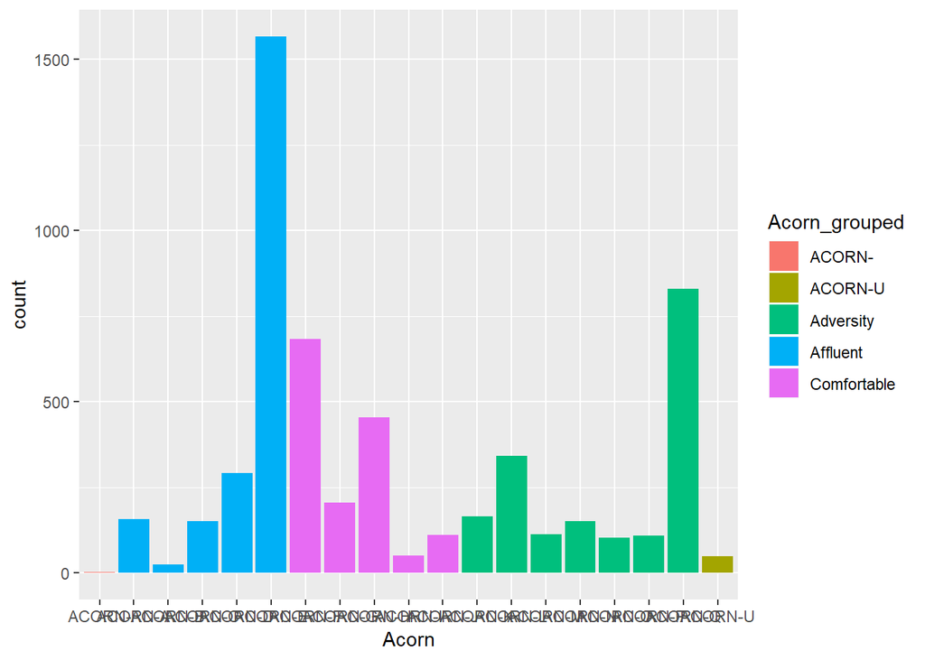

```r
ggplot(informations_households,aes(x=Acorn,fill=Acorn_grouped))+geom_bar()
```

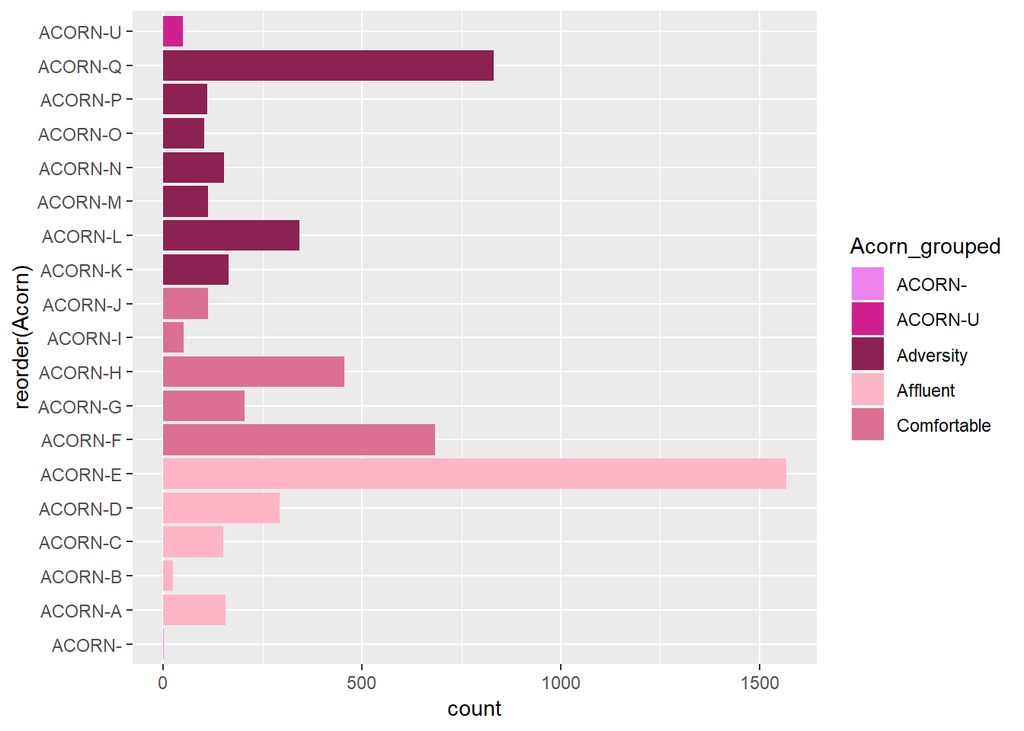

```r
ggplot(informations_households,aes(x=reorder(Acorn),fill=Acorn_grouped))+geom_bar()+coord_flip()+scale_fill_manual(values= c("violet", "violetred",           "violetred4" ,   "pink1","palevioletred"))
```

```r
informations_households[(informations_households$Acorn=="ACORN-"),]
```

```
##       LCLid stdorToU  Acorn Acorn_grouped    file
## 1 MAC005492      ToU ACORN-        ACORN- block_0
## 2 MAC001074      ToU ACORN-        ACORN- block_0
```

```r
informations_households[(informations_households$file=="block_0"),]
```

```
##        LCLid stdorToU   Acorn Acorn_grouped    file
## 1  MAC005492      ToU  ACORN-        ACORN- block_0
## 2  MAC001074      ToU  ACORN-        ACORN- block_0
## 3  MAC000002      Std ACORN-A      Affluent block_0
## 4  MAC003613      Std ACORN-A      Affluent block_0
## 5  MAC003597      Std ACORN-A      Affluent block_0
## 6  MAC003579      Std ACORN-A      Affluent block_0
## 7  MAC003566      Std ACORN-A      Affluent block_0
## 8  MAC003557      Std ACORN-A      Affluent block_0
## 9  MAC003553      Std ACORN-A      Affluent block_0
## 10 MAC003482      Std ACORN-A      Affluent block_0
## 11 MAC003463      Std ACORN-A      Affluent block_0
## 12 MAC003449      Std ACORN-A      Affluent block_0
## 13 MAC003428      Std ACORN-A      Affluent block_0
## 14 MAC003423      Std ACORN-A      Affluent block_0
```

[output cut: 36 more lines]

```r
#file-Acorn grouped

#Taula freq??ncies
taula<-table(informations_households$file,informations_households$Acorn_grouped)
taula
```

```
##
##             ACORN- ACORN-U Adversity Affluent Comfortable
##   block_0        2       0         0       48           0
##   block_1        0       0         0       50           0
##   block_10       0       0         0       50           0
##   block_100      0       0        50        0           0
##   block_101      0       0        50        0           0
##   block_102      0       0        50        0           0
##   block_103      0       0        50        0           0
##   block_104      0       0        50        0           0
##   block_105      0       0        50        0           0
##   block_106      0       0        50        0           0
##   block_107      0       0        50        0           0
##   block_108      0       0        50        0           0
##   block_109      0       0        50        0           0
##   block_11       0       0         0       50           0
##   block_110      0      33        17        0           0
##   block_111      0      16         0        0           0
##   block_12       0       0         0       50           0
##   block_13       0       0         0       50           0
##   block_14       0       0         0       50           0
##   block_15       0       0         0       50           0
##   block_16       0       0         0       50           0
##   block_17       0       0         0       50           0
##   block_18       0       0         0       50           0
##   block_19       0       0         0       50           0
##   block_2        0       0         0       50           0
##   block_20       0       0         0       50           0
##   block_21       0       0         0       50           0
##   block_22       0       0         0       50           0
##   block_23       0       0         0       50           0
##   block_24       0       0         0       50           0
##   block_25       0       0         0       50           0
##   block_26       0       0         0       50           0
##   block_27       0       0         0       50           0
##   block_28       0       0         0       50           0
##   block_29       0       0         0       50           0
##   block_3        0       0         0       50           0
##   block_30       0       0         0       50           0
##   block_31       0       0         0       50           0
```

[output cut: 59 more lines]

```
##   block_86       0       0        50        0           0
##   block_87       0       0        50        0           0
##   block_88       0       0        50        0           0
##   block_89       0       0        50        0           0
##   block_9        0       0         0       50           0
##   block_90       0       0        50        0           0
##   block_91       0       0        50        0           0
##   block_92       0       0        50        0           0
##   block_93       0       0        50        0           0
##   block_94       0       0        50        0           0
##   block_95       0       0        50        0           0
##   block_96       0       0        50        0           0
##   block_97       0       0        50        0           0
##   block_98       0       0        50        0           0
##   block_99       0       0        50        0           0
```

```r
#Taules creuades relatives percentatge total
prop.table(table(informations_households$file,informations_households$Acorn_grouped))*100
```

```
##
##                 ACORN-    ACORN-U  Adversity   Affluent Comfortable
##   block_0   0.03593245 0.00000000 0.00000000 0.86237873  0.00000000
##   block_1   0.00000000 0.00000000 0.00000000 0.89831117  0.00000000
##   block_10  0.00000000 0.00000000 0.00000000 0.89831117  0.00000000
##   block_100 0.00000000 0.00000000 0.89831117 0.00000000  0.00000000
##   block_101 0.00000000 0.00000000 0.89831117 0.00000000  0.00000000
##   block_102 0.00000000 0.00000000 0.89831117 0.00000000  0.00000000
##   block_103 0.00000000 0.00000000 0.89831117 0.00000000  0.00000000
##   block_104 0.00000000 0.00000000 0.89831117 0.00000000  0.00000000
##   block_105 0.00000000 0.00000000 0.89831117 0.00000000  0.00000000
##   block_106 0.00000000 0.00000000 0.89831117 0.00000000  0.00000000
##   block_107 0.00000000 0.00000000 0.89831117 0.00000000  0.00000000
##   block_108 0.00000000 0.00000000 0.89831117 0.00000000  0.00000000
##   block_109 0.00000000 0.00000000 0.89831117 0.00000000  0.00000000
##   block_11  0.00000000 0.00000000 0.00000000 0.89831117  0.00000000
##   block_110 0.00000000 0.59288538 0.30542580 0.00000000  0.00000000
##   block_111 0.00000000 0.28745958 0.00000000 0.00000000  0.00000000
##   block_12  0.00000000 0.00000000 0.00000000 0.89831117  0.00000000
##   block_13  0.00000000 0.00000000 0.00000000 0.89831117  0.00000000
##   block_14  0.00000000 0.00000000 0.00000000 0.89831117  0.00000000
##   block_15  0.00000000 0.00000000 0.00000000 0.89831117  0.00000000
##   block_16  0.00000000 0.00000000 0.00000000 0.89831117  0.00000000
##   block_17  0.00000000 0.00000000 0.00000000 0.89831117  0.00000000
##   block_18  0.00000000 0.00000000 0.00000000 0.89831117  0.00000000
##   block_19  0.00000000 0.00000000 0.00000000 0.89831117  0.00000000
##   block_2   0.00000000 0.00000000 0.00000000 0.89831117  0.00000000
##   block_20  0.00000000 0.00000000 0.00000000 0.89831117  0.00000000
##   block_21  0.00000000 0.00000000 0.00000000 0.89831117  0.00000000
##   block_22  0.00000000 0.00000000 0.00000000 0.89831117  0.00000000
##   block_23  0.00000000 0.00000000 0.00000000 0.89831117  0.00000000
##   block_24  0.00000000 0.00000000 0.00000000 0.89831117  0.00000000
##   block_25  0.00000000 0.00000000 0.00000000 0.89831117  0.00000000
##   block_26  0.00000000 0.00000000 0.00000000 0.89831117  0.00000000
##   block_27  0.00000000 0.00000000 0.00000000 0.89831117  0.00000000
##   block_28  0.00000000 0.00000000 0.00000000 0.89831117  0.00000000
##   block_29  0.00000000 0.00000000 0.00000000 0.89831117  0.00000000
##   block_3   0.00000000 0.00000000 0.00000000 0.89831117  0.00000000
##   block_30  0.00000000 0.00000000 0.00000000 0.89831117  0.00000000
##   block_31  0.00000000 0.00000000 0.00000000 0.89831117  0.00000000
```

[output cut: 59 more lines]

```
##   block_86  0.00000000 0.00000000 0.89831117 0.00000000  0.00000000
##   block_87  0.00000000 0.00000000 0.89831117 0.00000000  0.00000000
##   block_88  0.00000000 0.00000000 0.89831117 0.00000000  0.00000000
##   block_89  0.00000000 0.00000000 0.89831117 0.00000000  0.00000000
##   block_9   0.00000000 0.00000000 0.00000000 0.89831117  0.00000000
##   block_90  0.00000000 0.00000000 0.89831117 0.00000000  0.00000000
##   block_91  0.00000000 0.00000000 0.89831117 0.00000000  0.00000000
##   block_92  0.00000000 0.00000000 0.89831117 0.00000000  0.00000000
##   block_93  0.00000000 0.00000000 0.89831117 0.00000000  0.00000000
##   block_94  0.00000000 0.00000000 0.89831117 0.00000000  0.00000000
##   block_95  0.00000000 0.00000000 0.89831117 0.00000000  0.00000000
##   block_96  0.00000000 0.00000000 0.89831117 0.00000000  0.00000000
##   block_97  0.00000000 0.00000000 0.89831117 0.00000000  0.00000000
##   block_98  0.00000000 0.00000000 0.89831117 0.00000000  0.00000000
##   block_99  0.00000000 0.00000000 0.89831117 0.00000000  0.00000000
```

```r
#Taules creuades relatives percentatge per files
prop.table(table(informations_households$file,informations_households$Acorn_grouped),1)
```

```
##
##             ACORN- ACORN-U Adversity Affluent Comfortable
##   block_0     0.04    0.00      0.00     0.96        0.00
##   block_1     0.00    0.00      0.00     1.00        0.00
##   block_10    0.00    0.00      0.00     1.00        0.00
##   block_100   0.00    0.00      1.00     0.00        0.00
##   block_101   0.00    0.00      1.00     0.00        0.00
##   block_102   0.00    0.00      1.00     0.00        0.00
##   block_103   0.00    0.00      1.00     0.00        0.00
##   block_104   0.00    0.00      1.00     0.00        0.00
##   block_105   0.00    0.00      1.00     0.00        0.00
##   block_106   0.00    0.00      1.00     0.00        0.00
##   block_107   0.00    0.00      1.00     0.00        0.00
##   block_108   0.00    0.00      1.00     0.00        0.00
##   block_109   0.00    0.00      1.00     0.00        0.00
##   block_11    0.00    0.00      0.00     1.00        0.00
##   block_110   0.00    0.66      0.34     0.00        0.00
##   block_111   0.00    1.00      0.00     0.00        0.00
##   block_12    0.00    0.00      0.00     1.00        0.00
##   block_13    0.00    0.00      0.00     1.00        0.00
##   block_14    0.00    0.00      0.00     1.00        0.00
##   block_15    0.00    0.00      0.00     1.00        0.00
##   block_16    0.00    0.00      0.00     1.00        0.00
##   block_17    0.00    0.00      0.00     1.00        0.00
##   block_18    0.00    0.00      0.00     1.00        0.00
##   block_19    0.00    0.00      0.00     1.00        0.00
##   block_2     0.00    0.00      0.00     1.00        0.00
##   block_20    0.00    0.00      0.00     1.00        0.00
##   block_21    0.00    0.00      0.00     1.00        0.00
##   block_22    0.00    0.00      0.00     1.00        0.00
##   block_23    0.00    0.00      0.00     1.00        0.00
##   block_24    0.00    0.00      0.00     1.00        0.00
##   block_25    0.00    0.00      0.00     1.00        0.00
##   block_26    0.00    0.00      0.00     1.00        0.00
##   block_27    0.00    0.00      0.00     1.00        0.00
##   block_28    0.00    0.00      0.00     1.00        0.00
##   block_29    0.00    0.00      0.00     1.00        0.00
##   block_3     0.00    0.00      0.00     1.00        0.00
##   block_30    0.00    0.00      0.00     1.00        0.00
##   block_31    0.00    0.00      0.00     1.00        0.00
```

[output cut: 59 more lines]

```
##   block_86    0.00    0.00      1.00     0.00        0.00
##   block_87    0.00    0.00      1.00     0.00        0.00
##   block_88    0.00    0.00      1.00     0.00        0.00
##   block_89    0.00    0.00      1.00     0.00        0.00
##   block_9     0.00    0.00      0.00     1.00        0.00
##   block_90    0.00    0.00      1.00     0.00        0.00
##   block_91    0.00    0.00      1.00     0.00        0.00
##   block_92    0.00    0.00      1.00     0.00        0.00
##   block_93    0.00    0.00      1.00     0.00        0.00
##   block_94    0.00    0.00      1.00     0.00        0.00
##   block_95    0.00    0.00      1.00     0.00        0.00
##   block_96    0.00    0.00      1.00     0.00        0.00
##   block_97    0.00    0.00      1.00     0.00        0.00
##   block_98    0.00    0.00      1.00     0.00        0.00
##   block_99    0.00    0.00      1.00     0.00        0.00
```

```r
#Taules creuades relatives percentatge per columnes
prop.table(table(informations_households$file,informations_households$Acorn_grouped),2)
```

```
##
##                  ACORN-     ACORN-U   Adversity    Affluent Comfortable
##   block_0   1.000000000 0.000000000 0.000000000 0.021897810 0.000000000
##   block_1   0.000000000 0.000000000 0.000000000 0.022810219 0.000000000
##   block_10  0.000000000 0.000000000 0.000000000 0.022810219 0.000000000
##   block_100 0.000000000 0.000000000 0.027533040 0.000000000 0.000000000
##   block_101 0.000000000 0.000000000 0.027533040 0.000000000 0.000000000
##   block_102 0.000000000 0.000000000 0.027533040 0.000000000 0.000000000
##   block_103 0.000000000 0.000000000 0.027533040 0.000000000 0.000000000
##   block_104 0.000000000 0.000000000 0.027533040 0.000000000 0.000000000
##   block_105 0.000000000 0.000000000 0.027533040 0.000000000 0.000000000
##   block_106 0.000000000 0.000000000 0.027533040 0.000000000 0.000000000
##   block_107 0.000000000 0.000000000 0.027533040 0.000000000 0.000000000
##   block_108 0.000000000 0.000000000 0.027533040 0.000000000 0.000000000
##   block_109 0.000000000 0.000000000 0.027533040 0.000000000 0.000000000
##   block_11  0.000000000 0.000000000 0.000000000 0.022810219 0.000000000
##   block_110 0.000000000 0.673469388 0.009361233 0.000000000 0.000000000
##   block_111 0.000000000 0.326530612 0.000000000 0.000000000 0.000000000
##   block_12  0.000000000 0.000000000 0.000000000 0.022810219 0.000000000
##   block_13  0.000000000 0.000000000 0.000000000 0.022810219 0.000000000
##   block_14  0.000000000 0.000000000 0.000000000 0.022810219 0.000000000
##   block_15  0.000000000 0.000000000 0.000000000 0.022810219 0.000000000
##   block_16  0.000000000 0.000000000 0.000000000 0.022810219 0.000000000
##   block_17  0.000000000 0.000000000 0.000000000 0.022810219 0.000000000
##   block_18  0.000000000 0.000000000 0.000000000 0.022810219 0.000000000
##   block_19  0.000000000 0.000000000 0.000000000 0.022810219 0.000000000
##   block_2   0.000000000 0.000000000 0.000000000 0.022810219 0.000000000
##   block_20  0.000000000 0.000000000 0.000000000 0.022810219 0.000000000
##   block_21  0.000000000 0.000000000 0.000000000 0.022810219 0.000000000
##   block_22  0.000000000 0.000000000 0.000000000 0.022810219 0.000000000
##   block_23  0.000000000 0.000000000 0.000000000 0.022810219 0.000000000
##   block_24  0.000000000 0.000000000 0.000000000 0.022810219 0.000000000
##   block_25  0.000000000 0.000000000 0.000000000 0.022810219 0.000000000
##   block_26  0.000000000 0.000000000 0.000000000 0.022810219 0.000000000
##   block_27  0.000000000 0.000000000 0.000000000 0.022810219 0.000000000
##   block_28  0.000000000 0.000000000 0.000000000 0.022810219 0.000000000
##   block_29  0.000000000 0.000000000 0.000000000 0.022810219 0.000000000
##   block_3   0.000000000 0.000000000 0.000000000 0.022810219 0.000000000
##   block_30  0.000000000 0.000000000 0.000000000 0.022810219 0.000000000
##   block_31  0.000000000 0.000000000 0.000000000 0.022810219 0.000000000
```

[output cut: 59 more lines]

```
##   block_86  0.000000000 0.000000000 0.027533040 0.000000000 0.000000000
##   block_87  0.000000000 0.000000000 0.027533040 0.000000000 0.000000000
##   block_88  0.000000000 0.000000000 0.027533040 0.000000000 0.000000000
##   block_89  0.000000000 0.000000000 0.027533040 0.000000000 0.000000000
##   block_9   0.000000000 0.000000000 0.000000000 0.022810219 0.000000000
##   block_90  0.000000000 0.000000000 0.027533040 0.000000000 0.000000000
##   block_91  0.000000000 0.000000000 0.027533040 0.000000000 0.000000000
##   block_92  0.000000000 0.000000000 0.027533040 0.000000000 0.000000000
##   block_93  0.000000000 0.000000000 0.027533040 0.000000000 0.000000000
##   block_94  0.000000000 0.000000000 0.027533040 0.000000000 0.000000000
##   block_95  0.000000000 0.000000000 0.027533040 0.000000000 0.000000000
##   block_96  0.000000000 0.000000000 0.027533040 0.000000000 0.000000000
##   block_97  0.000000000 0.000000000 0.027533040 0.000000000 0.000000000
##   block_98  0.000000000 0.000000000 0.027533040 0.000000000 0.000000000
##   block_99  0.000000000 0.000000000 0.027533040 0.000000000 0.000000000
```

Ho veiem millor en gràfic

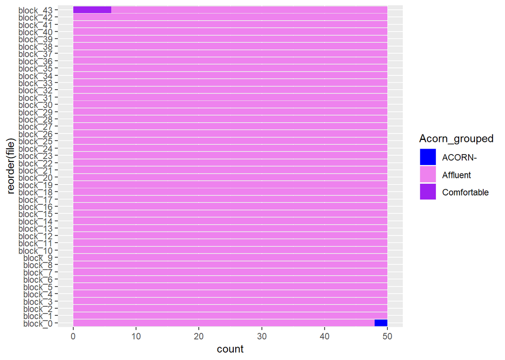

```r
#gràfic file-Acorn_grouped
cols<-informations_households$Acorn_grouped

ggplot(informations_households[1:2200,],aes(x=reorder(file),fill=Acorn_grouped) )+geom_bar()+ coord_flip()+scale_fill_manual(values=c("blue", "violet", "purple"))
```

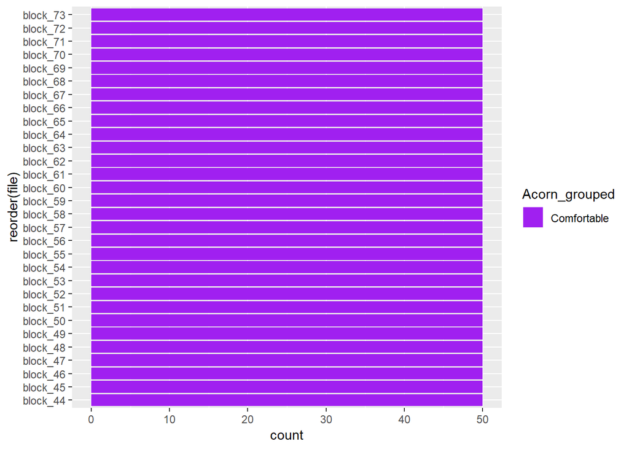

```r
ggplot(informations_households[2201:3700,],aes(x=reorder(file),fill=Acorn_grouped))+geom_bar()+ coord_flip()+scale_fill_manual(values=c("purple"))
```

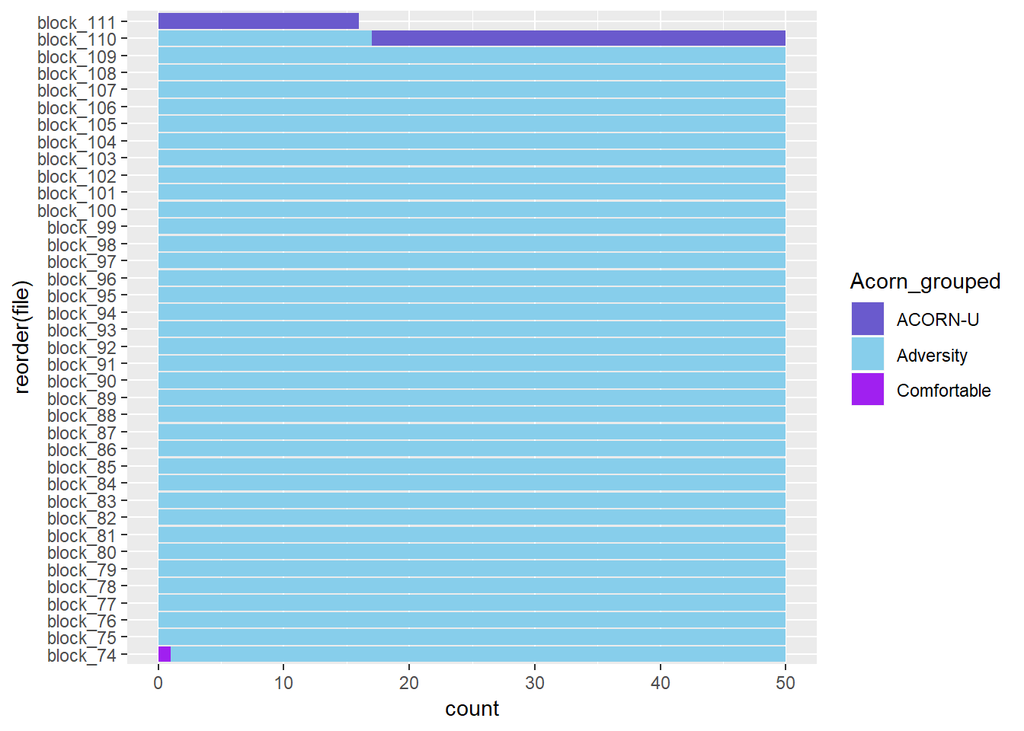

```r
ggplot(informations_households[3701:5566,],aes(x=reorder(file),fill=Acorn_grouped))+geom_bar()+ coord_flip()+scale_fill_manual(values=c( "slateblue", "skyblue","purple"))
```

```r
#file-Acorn
 options(max.print = 2000)
#Taula freq??ncies
table(informations_households$file,informations_households$Acorn)
```

```
##
##             ACORN- ACORN-A ACORN-B ACORN-C ACORN-D ACORN-E ACORN-F ACORN-G
##   block_0        2      48       0       0       0       0       0       0
##   block_1        0      50       0       0       0       0       0       0
##   block_10       0       0       0       0      50       0       0       0
##   block_100      0       0       0       0       0       0       0       0
##   block_101      0       0       0       0       0       0       0       0
##   block_102      0       0       0       0       0       0       0       0
##   block_103      0       0       0       0       0       0       0       0
##   block_104      0       0       0       0       0       0       0       0
##   block_105      0       0       0       0       0       0       0       0
##   block_106      0       0       0       0       0       0       0       0
##   block_107      0       0       0       0       0       0       0       0
##   block_108      0       0       0       0       0       0       0       0
##   block_109      0       0       0       0       0       0       0       0
##   block_11       0       0       0       0      50       0       0       0
##   block_110      0       0       0       0       0       0       0       0
##   block_111      0       0       0       0       0       0       0       0
##   block_12       0       0       0       0      27      23       0       0
##   block_13       0       0       0       0       0      50       0       0
##   block_14       0       0       0       0       0      50       0       0
##   block_15       0       0       0       0       0      50       0       0
##   block_16       0       0       0       0       0      50       0       0
##   block_17       0       0       0       0       0      50       0       0
##   block_18       0       0       0       0       0      50       0       0
##   block_19       0       0       0       0       0      50       0       0
##   block_2        0      50       0       0       0       0       0       0
##   block_20       0       0       0       0       0      50       0       0
##   block_21       0       0       0       0       0      50       0       0
##   block_22       0       0       0       0       0      50       0       0
##   block_23       0       0       0       0       0      50       0       0
##   block_24       0       0       0       0       0      50       0       0
##   block_25       0       0       0       0       0      50       0       0
##   block_26       0       0       0       0       0      50       0       0
##   block_27       0       0       0       0       0      50       0       0
##   block_28       0       0       0       0       0      50       0       0
##   block_29       0       0       0       0       0      50       0       0
##   block_3        0       9      25      16       0       0       0       0
##   block_30       0       0       0       0       0      50       0       0
##   block_31       0       0       0       0       0      50       0       0
```

[output cut: 267 more lines]

```
##   block_80        0       0       0       0
##   block_81        0       0       0       0
##   block_82        0       0       0       0
##   block_83        0       0       0       0
##   block_84        0       0       0       0
##   block_85        0       0       0       0
##   block_86        0       0       0       0
##   block_87        0       0       0       0
##   block_88        0       0       0       0
##   block_89       27       0       0       0
##   block_9         0       0       0       0
##   block_90       50       0       0       0
##   block_91       26      24       0       0
##   block_92        0      50       0       0
##  [ reached getOption("max.print") -- omitted 7 rows ]
```

```r
library(RPMG)
colors()
```

[output not shown]

[output cut: 204 more lines]

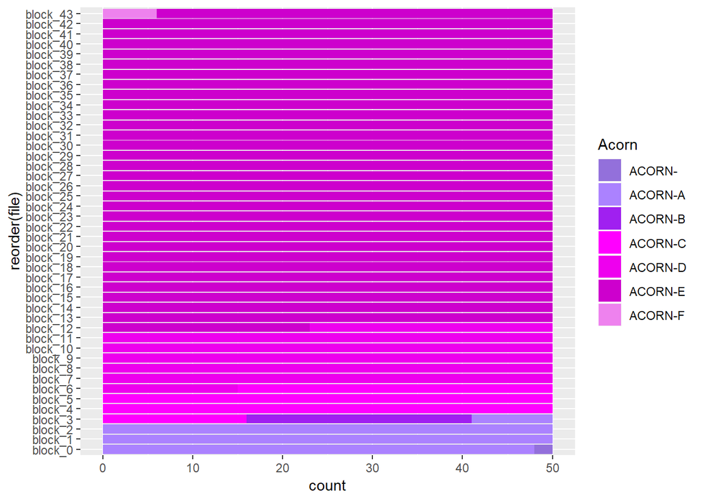

```r
#gràfic file-Acorn
ggplot(informations_households[1:2200,],aes(x=reorder(file),fill=Acorn))+geom_bar()+coord_flip()+scale_fill_manual(values=c("mediumpurple" , "mediumpurple1" , "purple", "magenta" ,"magenta2" ,"magenta3", "violet"  ))
```

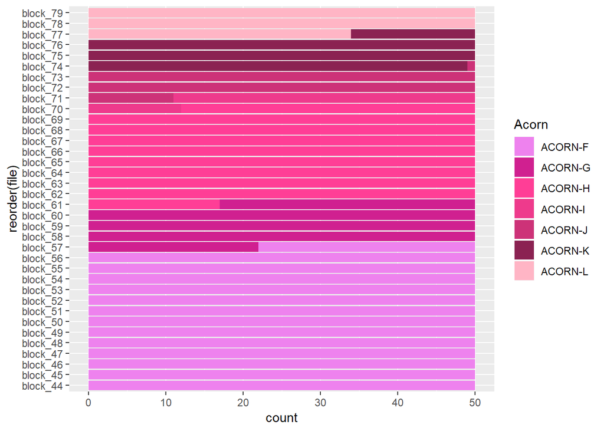

```r
ggplot(informations_households[2201:4000,],aes(x=reorder(file),fill=Acorn))+geom_bar()+coord_flip()+scale_fill_manual(values= c("violet", "violetred",    "violetred1"  ,        "violetred2"   ,        "violetred3" ,  "violetred4" , "pink1"))
```

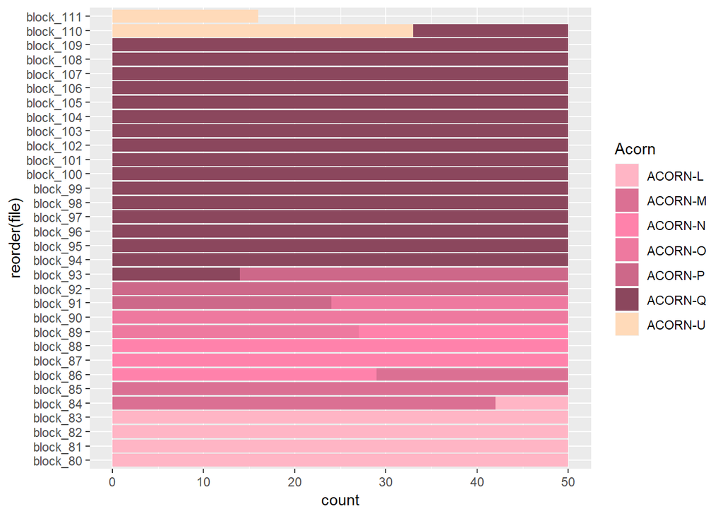

```r
ggplot(informations_households[4001:5566,],aes(x=reorder(file),fill=Acorn))+geom_bar()+ coord_flip()+scale_fill_manual(values= c( "pink1", "palevioletred", "palevioletred1", "palevioletred2", "palevioletred3"  ,     "palevioletred4"  , "peachpuff" ))
```

Veiem que a mesura que augmenta l’Acorn, aumenta el número de block, és a dir els de l’Acorn A estan al bloc_0 , block_1 i block_2, els de l’Acorn B estan al block_3 els de l’acorn C al block_3, block_4, block_5 i block_ 6 i així successivament. Per lògica doncs, intuïm que els de l’Acorn- que estan al block 0 han de ser ACORN-A. I com que els de l’ACORN-A són Affluent, per lògica entenem que aquests valors també ho seran. El mateix amb els valors de l’ACORN-U, que estan tots als blocs 110 i 111, i els últims blocs són els que corresponen a Adversity.

Els tractem:

```r
informations_households$Acorn_grouped[informations_households$Acorn_grouped== "ACORN-"]<- "Affluent"

informations_households$Acorn[informations_households$Acorn== "ACORN-"]<- "ACORN-A"

informations_households$Acorn_grouped[informations_households$Acorn_grouped== "ACORN-U"]<- "Adversity"
```

Un cop tractades les dades, mirem si conté valors buits.

```r
#Mirem si cont? valors buits
colSums(is.na(informations_households))
```

```
##         LCLid      stdorToU         Acorn Acorn_grouped          file
##             0             0             0             0             0
```

```r
colSums(informations_households=="")
```

```
##         LCLid      stdorToU         Acorn Acorn_grouped          file
##             0             0             0             0             0
```

Veiem que cap variable cont? valors buits.

## Gr?fic

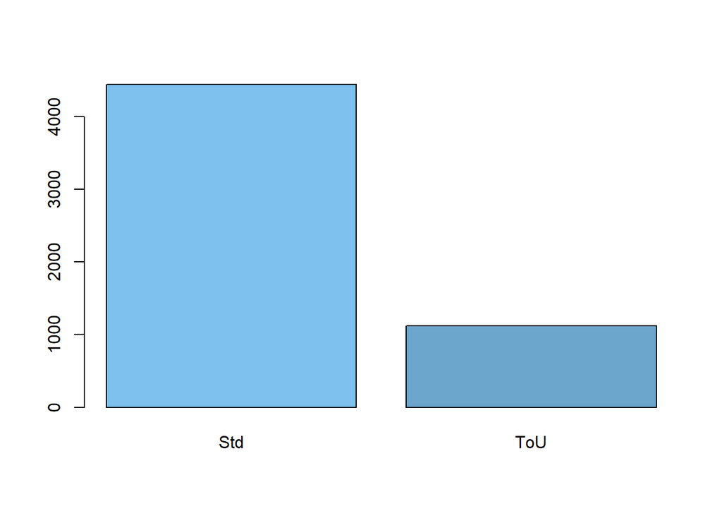

```r
plot(x=informations_households$stdorToU,col=colors()[591:600])
```

```r
prop.table(table(informations_households$stdorToU))*100
```

```
##
##      Std      ToU
## 79.82393 20.17607
```

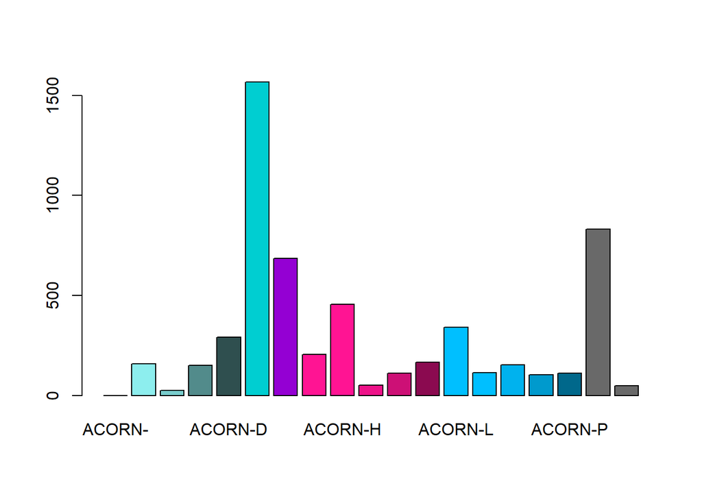

```r
plot(x=informations_households$Acorn, col=colors()[109:300])
```

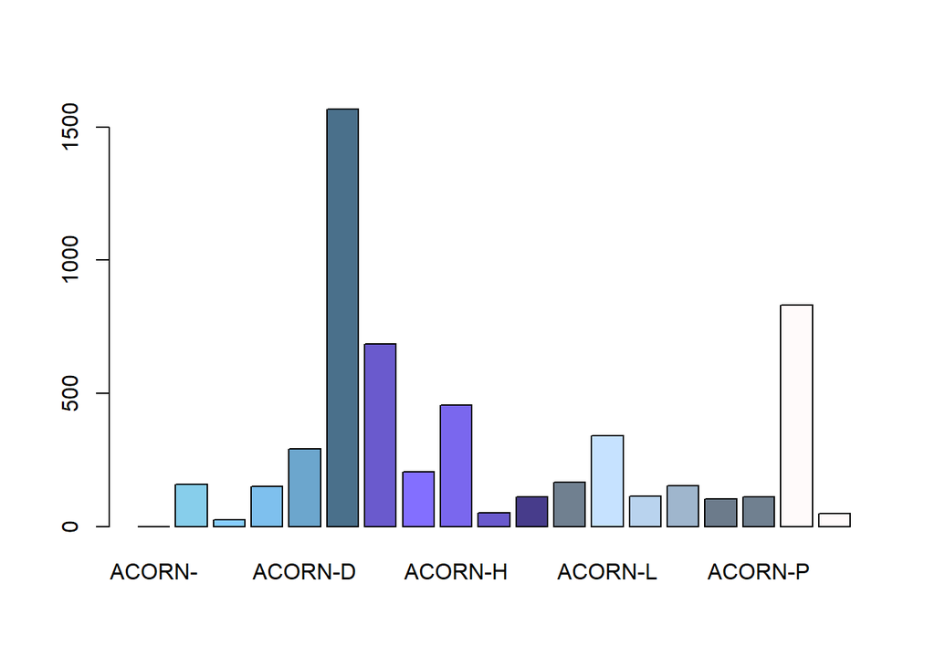

```r
plot(x=informations_households$Acorn, col=colors()[588:1300])
```

```r
prop.table(table(informations_households$Acorn))*100
```

```
##
##     ACORN-    ACORN-A    ACORN-B    ACORN-C    ACORN-D    ACORN-E
##  0.0000000  2.8566295  0.4491556  2.7128997  5.2461373 28.1530722
##    ACORN-F    ACORN-G    ACORN-H    ACORN-I    ACORN-J    ACORN-K
## 12.2888969  3.6830758  8.1746317  0.9162774  2.0122170  2.9644269
##    ACORN-L    ACORN-M    ACORN-N    ACORN-O    ACORN-P    ACORN-Q
##  6.1444484  2.0301833  2.7308660  1.8505210  1.9762846 14.9299317
##    ACORN-U
##  0.8803450
```

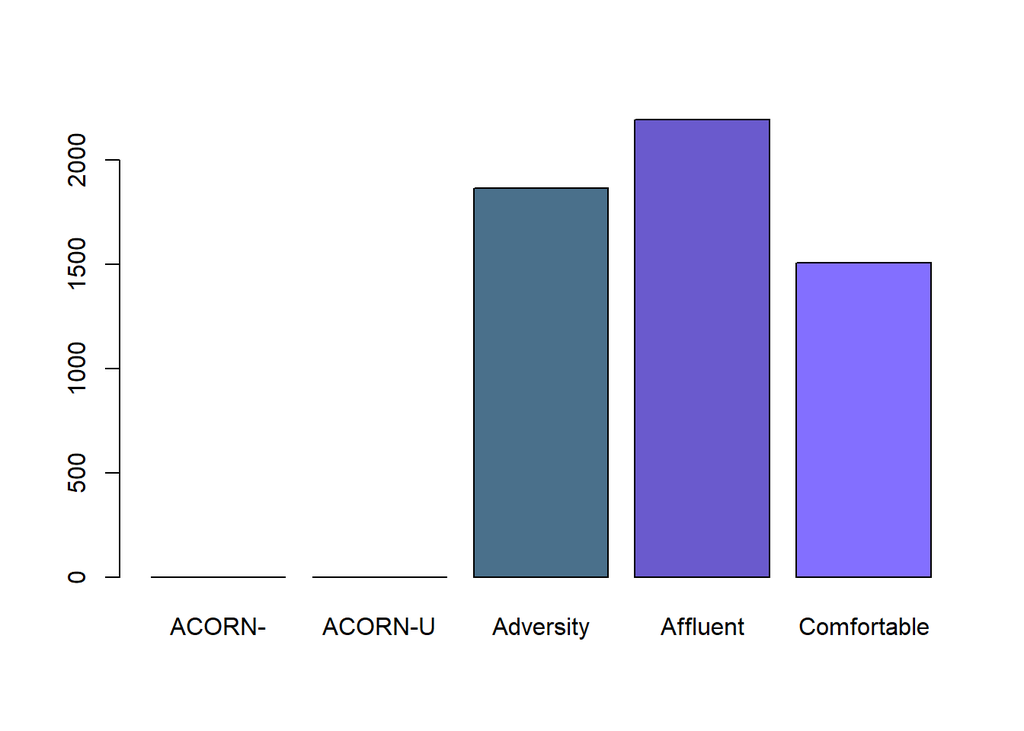

```r
plot(x=informations_households$Acorn_grouped,col=colors()[591:600])
```

```r
prop.table(table(informations_households$Acorn_grouped))*100
```

```
##
##      ACORN-     ACORN-U   Adversity    Affluent Comfortable
##     0.00000     0.00000    33.50701    39.41789    27.07510
```

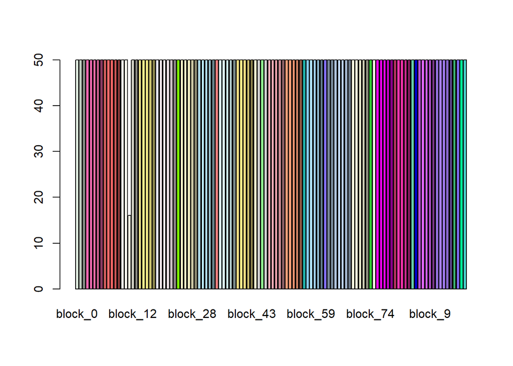

```r
plot(x=informations_households$file,col=colors()[364:600])
```

```r
prop.table(table(informations_households$file))*100
```

```
##
##   block_0   block_1  block_10 block_100 block_101 block_102 block_103
## 0.8983112 0.8983112 0.8983112 0.8983112 0.8983112 0.8983112 0.8983112
## block_104 block_105 block_106 block_107 block_108 block_109  block_11
## 0.8983112 0.8983112 0.8983112 0.8983112 0.8983112 0.8983112 0.8983112
## block_110 block_111  block_12  block_13  block_14  block_15  block_16
## 0.8983112 0.2874596 0.8983112 0.8983112 0.8983112 0.8983112 0.8983112
##  block_17  block_18  block_19   block_2  block_20  block_21  block_22
## 0.8983112 0.8983112 0.8983112 0.8983112 0.8983112 0.8983112 0.8983112
##  block_23  block_24  block_25  block_26  block_27  block_28  block_29
## 0.8983112 0.8983112 0.8983112 0.8983112 0.8983112 0.8983112 0.8983112
##   block_3  block_30  block_31  block_32  block_33  block_34  block_35
## 0.8983112 0.8983112 0.8983112 0.8983112 0.8983112 0.8983112 0.8983112
##  block_36  block_37  block_38  block_39   block_4  block_40  block_41
## 0.8983112 0.8983112 0.8983112 0.8983112 0.8983112 0.8983112 0.8983112
##  block_42  block_43  block_44  block_45  block_46  block_47  block_48
## 0.8983112 0.8983112 0.8983112 0.8983112 0.8983112 0.8983112 0.8983112
##  block_49   block_5  block_50  block_51  block_52  block_53  block_54
## 0.8983112 0.8983112 0.8983112 0.8983112 0.8983112 0.8983112 0.8983112
##  block_55  block_56  block_57  block_58  block_59   block_6  block_60
## 0.8983112 0.8983112 0.8983112 0.8983112 0.8983112 0.8983112 0.8983112
##  block_61  block_62  block_63  block_64  block_65  block_66  block_67
## 0.8983112 0.8983112 0.8983112 0.8983112 0.8983112 0.8983112 0.8983112
##  block_68  block_69   block_7  block_70  block_71  block_72  block_73
## 0.8983112 0.8983112 0.8983112 0.8983112 0.8983112 0.8983112 0.8983112
##  block_74  block_75  block_76  block_77  block_78  block_79   block_8
## 0.8983112 0.8983112 0.8983112 0.8983112 0.8983112 0.8983112 0.8983112
##  block_80  block_81  block_82  block_83  block_84  block_85  block_86
## 0.8983112 0.8983112 0.8983112 0.8983112 0.8983112 0.8983112 0.8983112
##  block_87  block_88  block_89   block_9  block_90  block_91  block_92
## 0.8983112 0.8983112 0.8983112 0.8983112 0.8983112 0.8983112 0.8983112
##  block_93  block_94  block_95  block_96  block_97  block_98  block_99
## 0.8983112 0.8983112 0.8983112 0.8983112 0.8983112 0.8983112 0.8983112
```

```r
#Acorn-stdorToU

#Taula freq??ncies
table(informations_households$Acorn,informations_households$stdorToU)
```

```
##
##            Std  ToU
##   ACORN-     0    0
##   ACORN-A  118   41
##   ACORN-B   21    4
##   ACORN-C  116   35
##   ACORN-D  219   73
##   ACORN-E 1228  339
##   ACORN-F  531  153
##   ACORN-G  158   47
##   ACORN-H  371   84
##   ACORN-I   43    8
##   ACORN-J   81   31
##   ACORN-K  143   22
##   ACORN-L  266   76
##   ACORN-M   96   17
##   ACORN-N  126   26
##   ACORN-O   87   16
##   ACORN-P   88   22
##   ACORN-Q  712  119
##   ACORN-U   39   10
```

```r
#Taules creuades relatives percentatge total
prop.table(table(informations_households$Acorn,informations_households$stdorToU))*100
```

```
##
##                   Std         ToU
##   ACORN-   0.00000000  0.00000000
##   ACORN-A  2.12001437  0.73661516
##   ACORN-B  0.37729069  0.07186489
##   ACORN-C  2.08408193  0.62881782
##   ACORN-D  3.93460295  1.31153432
##   ACORN-E 22.06252246  6.09054977
##   ACORN-F  9.54006468  2.74883220
##   ACORN-G  2.83866331  0.84441250
##   ACORN-H  6.66546892  1.50916277
##   ACORN-I  0.77254761  0.14372979
##   ACORN-J  1.45526410  0.55695293
##   ACORN-K  2.56916996  0.39525692
##   ACORN-L  4.77901545  1.36543299
##   ACORN-M  1.72475746  0.30542580
##   ACORN-N  2.26374416  0.46712181
##   ACORN-O  1.56306144  0.28745958
##   ACORN-P  1.58102767  0.39525692
##   ACORN-Q 12.79195113  2.13798060
##   ACORN-U  0.70068272  0.17966223
```

```r
#Taules creuades relatives percentatge per files
prop.table(table(informations_households$Acorn,informations_households$stdorToU),1)
```

```
##
##                 Std       ToU
##   ACORN-
##   ACORN-A 0.7421384 0.2578616
##   ACORN-B 0.8400000 0.1600000
##   ACORN-C 0.7682119 0.2317881
##   ACORN-D 0.7500000 0.2500000
##   ACORN-E 0.7836631 0.2163369
##   ACORN-F 0.7763158 0.2236842
##   ACORN-G 0.7707317 0.2292683
##   ACORN-H 0.8153846 0.1846154
##   ACORN-I 0.8431373 0.1568627
##   ACORN-J 0.7232143 0.2767857
##   ACORN-K 0.8666667 0.1333333
##   ACORN-L 0.7777778 0.2222222
##   ACORN-M 0.8495575 0.1504425
##   ACORN-N 0.8289474 0.1710526
##   ACORN-O 0.8446602 0.1553398
##   ACORN-P 0.8000000 0.2000000
##   ACORN-Q 0.8567990 0.1432010
##   ACORN-U 0.7959184 0.2040816
```

```r
#Taules creuades relatives percentatge per columnes
prop.table(table(informations_households$Acorn,informations_households$stdorToU),2)
```

```
##
##                   Std         ToU
##   ACORN-  0.000000000 0.000000000
##   ACORN-A 0.026558632 0.036509350
##   ACORN-B 0.004726536 0.003561888
##   ACORN-C 0.026108485 0.031166518
##   ACORN-D 0.049291020 0.065004452
##   ACORN-E 0.276389827 0.301869991
##   ACORN-F 0.119513842 0.136242208
##   ACORN-G 0.035561558 0.041852182
##   ACORN-H 0.083502138 0.074799644
##   ACORN-I 0.009678145 0.007123776
##   ACORN-J 0.018230925 0.027604630
##   ACORN-K 0.032185460 0.019590383
##   ACORN-L 0.059869458 0.067675868
##   ACORN-M 0.021607022 0.015138023
##   ACORN-N 0.028359217 0.023152271
##   ACORN-O 0.019581364 0.014247551
##   ACORN-P 0.019806437 0.019590383
##   ACORN-Q 0.160252082 0.105966162
##   ACORN-U 0.008777853 0.008904720
```

```r
#Acorn_grouped-stdorToU

#Taula freq??ncies
table(informations_households$Acorn_grouped,informations_households$stdorToU)
```

```
##
##                Std  ToU
##   ACORN-         0    0
##   ACORN-U        0    0
##   Adversity   1557  308
##   Affluent    1702  492
##   Comfortable 1184  323
```

```r
#Taules creuades relatives percentatge total
prop.table(table(informations_households$Acorn_grouped,informations_households$stdorToU))*100
```

```
##
##                     Std       ToU
##   ACORN-       0.000000  0.000000
##   ACORN-U      0.000000  0.000000
##   Adversity   27.973410  5.533597
##   Affluent    30.578512  8.839382
##   Comfortable 21.272009  5.803090
```

```r
#Taules creuades relatives percentatge per files
prop.table(table(informations_households$Acorn_grouped,informations_households$stdorToU),1)
```

```
##
##                     Std       ToU
##   ACORN-
##   ACORN-U
##   Adversity   0.8348525 0.1651475
##   Affluent    0.7757521 0.2242479
##   Comfortable 0.7856669 0.2143331
```

```r
#Taules creuades relatives percentatge per columnes
prop.table(table(informations_households$Acorn_grouped,informations_households$stdorToU),2)
```

```
##
##                     Std       ToU
##   ACORN-      0.0000000 0.0000000
##   ACORN-U     0.0000000 0.0000000
##   Adversity   0.3504389 0.2742654
##   Affluent    0.3830745 0.4381122
##   Comfortable 0.2664866 0.2876224
```

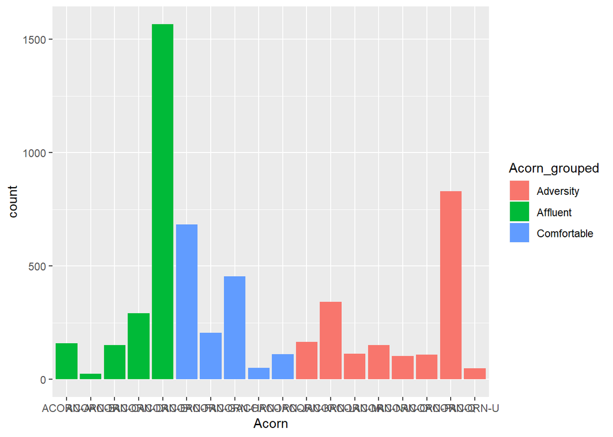

```r
ggplot(informations_households,aes(x=Acorn,fill=Acorn_grouped))+geom_bar()
```

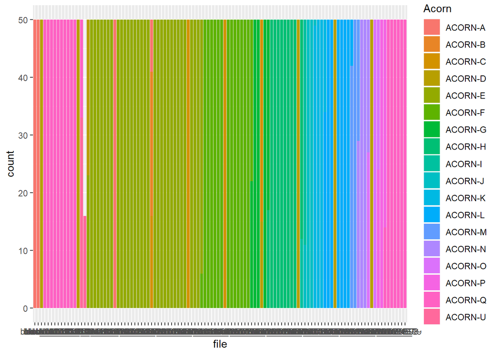

```r
ggplot(informations_households,aes(x=file,fill=Acorn))+geom_bar()
```

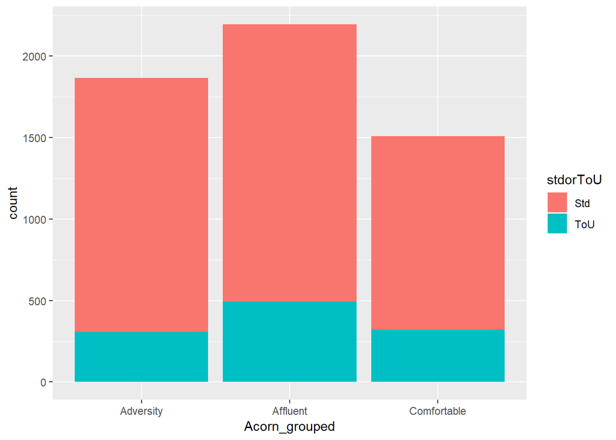

```r
ggplot(informations_households,aes(x=Acorn_grouped,fill=stdorToU))+geom_bar()
```

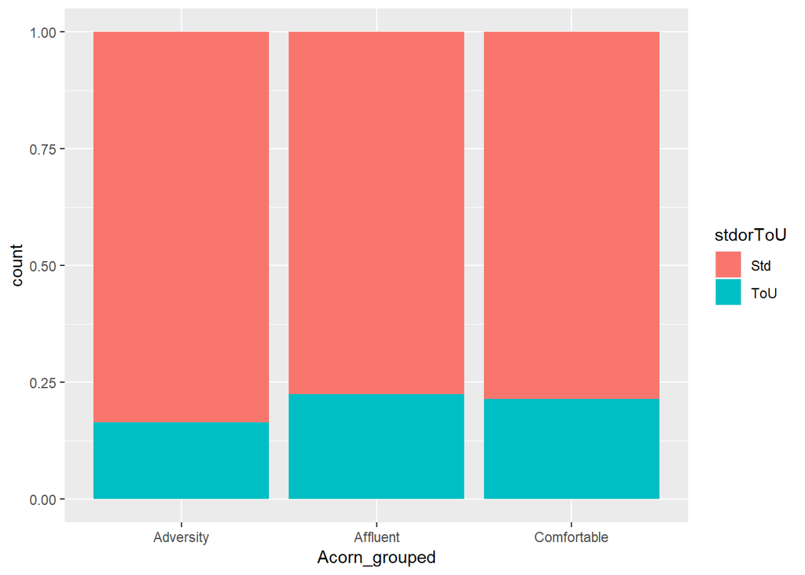

```r
ggplot(informations_households,aes(x=Acorn_grouped,fill=stdorToU))+geom_bar(position="fill")
```

# Arxiu acorn_details

```r
#Carreguem arxiu de dades
acorn_details <-read.csv(file="dades/4acorn_details.csv", header=TRUE, sep=",")
```

```r
#Resum dades

#Dimensi?
dim(acorn_details)
```

```
## [1] 826  20
```

```r
# Resum
summary(acorn_details)
```

```
##      MAIN.CATEGORIES                                   CATEGORIES
##  DIGITAL     :372    Sites regularly visited                : 85
##  FINANCE     : 94    Types of internet usage : Mobile Phone : 46
##  LEISURE TIME: 92    Types of internet usage : Laptop or PC : 45
##  SHOPPING    : 44    Types of internet usage : Tablet / iPad: 45
##  POPULATION  : 35    Purchased on the internet              : 40
##  ECONOMY     : 34    Regularly research on the internet     : 40
##  (Other)     :155    (Other)                                :525
##        REFERENCE      ACORN.A          ACORN.B           ACORN.C
##  Mass Market:  8   Min.   :  12.0   Min.   :  0.957   Min.   :  0.282
##  Premium    :  8   1st Qu.:  87.0   1st Qu.: 94.000   1st Qu.: 86.000
##  Value      :  8   Median : 104.0   Median :107.000   Median :100.000
##  By phone   :  5   Mean   : 131.3   Mean   :110.860   Mean   :100.081
##  By post    :  5   3rd Qu.: 128.0   3rd Qu.:122.000   3rd Qu.:113.000
##  Online     :  5   Max.   :3795.0   Max.   :419.000   Max.   :272.000
##  (Other)    :787
##     ACORN.D           ACORN.E         ACORN.F          ACORN.G
##  Min.   :   2.00   Min.   : 21.0   Min.   :  0.00   Min.   :  0.7914
##  1st Qu.:  93.09   1st Qu.: 99.0   1st Qu.: 81.00   1st Qu.: 94.1381
##  Median : 121.00   Median :117.0   Median : 98.00   Median :102.0000
##  Mean   : 136.86   Mean   :117.9   Mean   : 95.57   Mean   :101.4443
##  3rd Qu.: 154.00   3rd Qu.:135.0   3rd Qu.:108.00   3rd Qu.:109.0000
##  Max.   :1159.03   Max.   :286.0   Max.   :462.00   Max.   :295.0000
##
##     ACORN.H           ACORN.I           ACORN.J          ACORN.K
##  Min.   :  1.155   Min.   :  6.363   Min.   : 16.05   Min.   :  17.0
##  1st Qu.: 91.000   1st Qu.: 70.000   1st Qu.: 97.00   1st Qu.:  85.0
##  Median : 99.000   Median : 88.000   Median :105.00   Median : 109.0
##  Mean   : 97.299   Mean   : 87.028   Mean   :104.22   Mean   : 127.5
##  3rd Qu.:105.000   3rd Qu.:101.750   3rd Qu.:115.00   3rd Qu.: 144.0
##  Max.   :192.000   Max.   :410.000   Max.   :197.00   Max.   :1821.0
##
##     ACORN.L            ACORN.M            ACORN.N          ACORN.O
##  Min.   :  0.3936   Min.   :  0.7149   Min.   :  2.00   Min.   : 11.00
##  1st Qu.: 86.0000   1st Qu.: 82.0000   1st Qu.: 60.25   1st Qu.: 86.00
##  Median : 95.0000   Median : 93.0000   Median : 74.00   Median : 96.00
##  Mean   : 93.7242   Mean   : 91.4103   Mean   : 79.91   Mean   : 95.58
##  3rd Qu.:102.0000   3rd Qu.:101.0000   3rd Qu.: 93.16   3rd Qu.:104.00
##  Max.   :280.0000   Max.   :161.0000   Max.   :295.00   Max.   :252.00
##
##     ACORN.P          ACORN.Q
##  Min.   :  9.00   Min.   :  1.00
##  1st Qu.: 82.25   1st Qu.: 71.25
##  Median : 96.00   Median : 87.00
##  Mean   :100.14   Mean   : 90.86
##  3rd Qu.:109.00   3rd Qu.:101.00
##  Max.   :389.00   Max.   :326.00
##
```

```r
# Tipus de dades
str(acorn_details)
```

```
## 'data.frame':    826 obs. of  20 variables:
##  $ MAIN.CATEGORIES: Factor w/ 15 levels "COMMUNITY SAFETY",..: 13 13 13 13 13 13 13 13 13 13 ...
##  $ CATEGORIES     : Factor w/ 84 levels "Action","Age",..: 2 2 2 2 2 2 2 2 36 36 ...
##  $ REFERENCE      : Factor w/ 632 levels "£0-£20,000","£100,000+",..: 38 42 39 40 41 43 44 45 183 400 ...
##  $ ACORN.A        : num  77 117 64 52 102 124 125 112 107 30 ...
##  $ ACORN.B        : num  83 109 73 63 105 121 120 103 101 95 ...
##  $ ACORN.C        : num  72 87 67 62 91 120 152 157 103 45 ...
##  $ ACORN.D        : num  100 69 107 197 124 72 55 49 114 2 ...
##  $ ACORN.E        : num  120 94 100 151 118 82 61 57 106 49 ...
##  $ ACORN.F        : num  77 95 71 66 93 126 144 117 75 462 ...
##  $ ACORN.G        : num  97 102 83 90 102 109 108 98 107 53 ...
##  $ ACORN.H        : num  97 106 89 88 103 107 104 96 106 104 ...
##  $ ACORN.I        : num  63 67 62 63 76 112 182 220 102 30 ...
##  $ ACORN.J        : num  119 95 104 132 111 90 72 66 106 91 ...
##  $ ACORN.K        : num  67 64 459 145 67 41 29 32 95 56 ...
##  $ ACORN.L        : num  114 108 97 109 99 95 91 87 93 87 ...
##  $ ACORN.M        : num  113 116 96 96 98 96 93 96 97 131 ...
##  $ ACORN.N        : num  89 86 86 90 90 103 125 152 89 67 ...
##  $ ACORN.O        : num  123 89 117 140 102 89 73 72 97 95 ...
##  $ ACORN.P        : num  138 136 109 120 103 78 59 56 110 75 ...
##  $ ACORN.Q        : num  133 106 110 120 100 89 76 76 97 43 ...
```

```r
#Mirem si cont? valors buits
colSums(is.na(acorn_details))
```

```
## MAIN.CATEGORIES      CATEGORIES       REFERENCE         ACORN.A
##               0               0               0               0
##         ACORN.B         ACORN.C         ACORN.D         ACORN.E
##               0               0               0               0
##         ACORN.F         ACORN.G         ACORN.H         ACORN.I
##               0               0               0               0
##         ACORN.J         ACORN.K         ACORN.L         ACORN.M
##               0               0               0               0
##         ACORN.N         ACORN.O         ACORN.P         ACORN.Q
##               0               0               0               0
```

```r
colSums(acorn_details=="")
```

```
## MAIN.CATEGORIES      CATEGORIES       REFERENCE         ACORN.A
##               0               0               0               0
##         ACORN.B         ACORN.C         ACORN.D         ACORN.E
##               0               0               0               0
##         ACORN.F         ACORN.G         ACORN.H         ACORN.I
##               0               0               0               0
##         ACORN.J         ACORN.K         ACORN.L         ACORN.M
##               0               0               0               0
##         ACORN.N         ACORN.O         ACORN.P         ACORN.Q
##               0               0               0               0
```

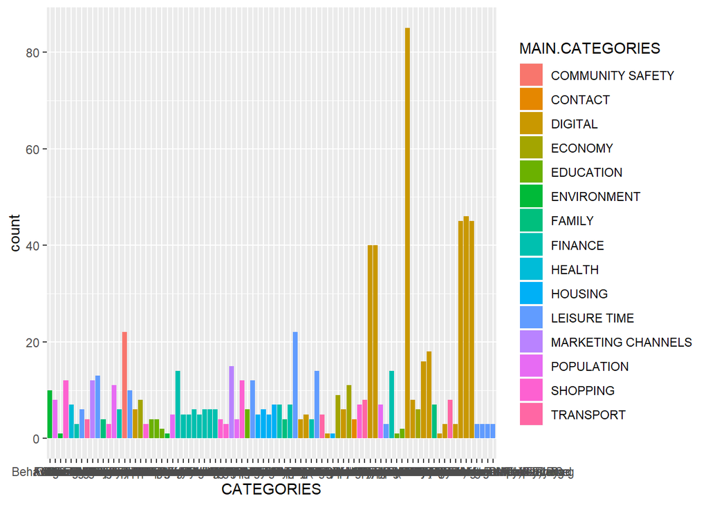

```r
ggplot(acorn_details,aes(x=CATEGORIES,fill=MAIN.CATEGORIES))+geom_bar()
```

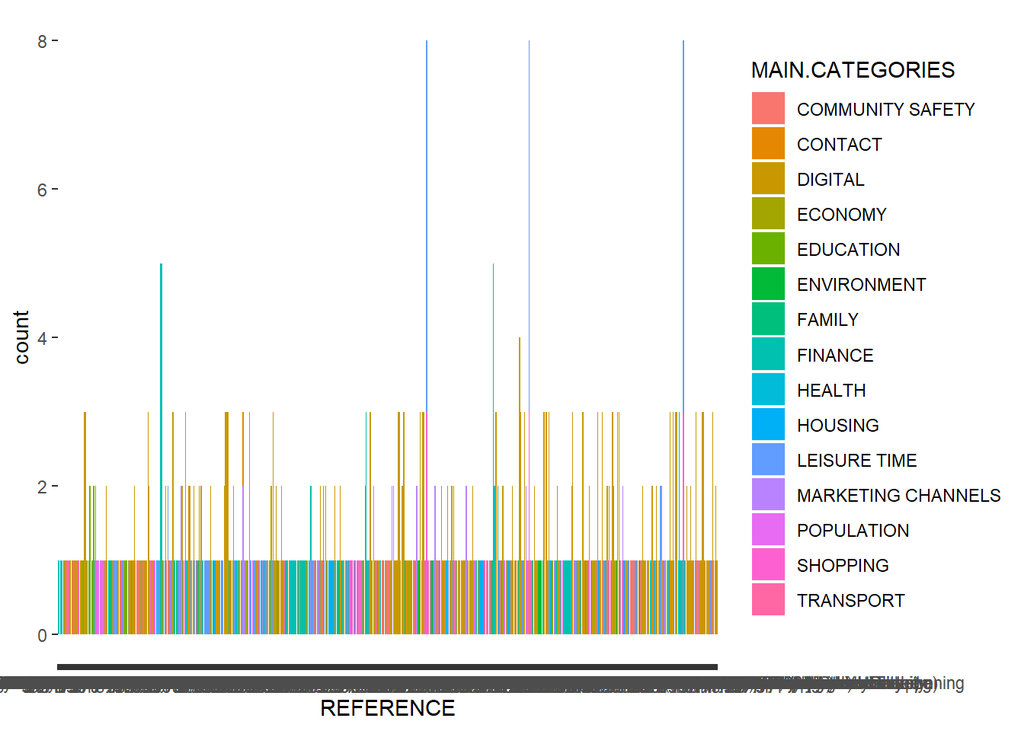

```r
ggplot(acorn_details,aes(x=REFERENCE,fill=MAIN.CATEGORIES))+geom_bar()
```

# Arxiu weather daily darksky

```r
#Carreguem arxiu de dades
weather_daily <-read.csv(file="dades/5weather_daily_darksky.csv", header=TRUE, sep=",")
```

```r
#Resum dades

#Dimensi?
dim(weather_daily)
```

```
## [1] 882  32
```

```r
# Resum
summary(weather_daily)
```

```
##  temperatureMax             temperatureMaxTime  windBearing
##  Min.   :-0.060   2011-11-01 15:00:00:  1      Min.   :  0.0
##  1st Qu.: 9.502   2011-11-02 23:00:00:  1      1st Qu.:120.5
##  Median :12.625   2011-11-03 14:00:00:  1      Median :219.0
##  Mean   :13.660   2011-11-04 11:00:00:  1      Mean   :195.7
##  3rd Qu.:17.920   2011-11-05 15:00:00:  1      3rd Qu.:255.0
##  Max.   :32.400   2011-11-06 14:00:00:  1      Max.   :359.0
##                   (Other)            :876
##                   icon        dewPoint               temperatureMinTime
##  clear-day          :  6   Min.   :-7.84   2011-11-01 22:00:00:  1
##  cloudy             :  9   1st Qu.: 3.18   2011-11-02 03:00:00:  1
##  fog                : 91   Median : 6.38   2011-11-03 21:00:00:  1
##  partly-cloudy-day  :619   Mean   : 6.53   2011-11-04 23:00:00:  1
##  partly-cloudy-night: 33   3rd Qu.:10.06   2011-11-05 02:00:00:  1
##  wind               :124   Max.   :17.77   2011-11-06 05:00:00:  1
##                                            (Other)            :876
##    cloudCover       windSpeed        pressure
##  Min.   :0.0000   Min.   :0.200   Min.   : 979.2
##  1st Qu.:0.3500   1st Qu.:2.370   1st Qu.:1007.4
##  Median :0.4700   Median :3.440   Median :1014.6
##  Mean   :0.4776   Mean   :3.582   Mean   :1014.1
##  3rd Qu.:0.6000   3rd Qu.:4.577   3rd Qu.:1021.8
##  Max.   :1.0000   Max.   :9.960   Max.   :1040.9
##  NA's   :1
##        apparentTemperatureMinTime apparentTemperatureHigh precipType
##  2011-11-01 22:00:00:  1          Min.   :-6.460          rain:862
##  2011-11-02 03:00:00:  1          1st Qu.: 7.032          snow: 20
##  2011-11-03 21:00:00:  1          Median :12.470
##  2011-11-04 23:00:00:  1          Mean   :12.724
##  2011-11-05 02:00:00:  1          3rd Qu.:17.910
##  2011-11-06 06:00:00:  1          Max.   :32.420
##  (Other)            :876
##    visibility       humidity           apparentTemperatureHighTime
##  Min.   : 1.48   Min.   :0.4300   2011-11-01 15:00:00:  1
##  1st Qu.:10.33   1st Qu.:0.7200   2011-11-02 13:00:00:  1
##  Median :11.97   Median :0.7900   2011-11-03 14:00:00:  1
##  Mean   :11.17   Mean   :0.7819   2011-11-04 11:00:00:  1
##  3rd Qu.:12.83   3rd Qu.:0.8600   2011-11-05 15:00:00:  1
##  Max.   :15.34   Max.   :0.9800   2011-11-06 14:00:00:  1
##                                   (Other)            :876
```

[output cut: 41 more lines]

```
##  Min.   :-8.880         2011-11-01 15:00:00:  1
##  1st Qu.: 1.105         2011-11-02 23:00:00:  1
##  Median : 4.885         2011-11-03 14:00:00:  1
##  Mean   : 5.738         2011-11-04 11:00:00:  1
##  3rd Qu.:11.277         2011-11-05 15:00:00:  1
##  Max.   :20.540         2011-11-06 14:00:00:  1
##                         (Other)            :876
##        apparentTemperatureLowTime   moonPhase
##  2011-11-02 03:00:00:  1          Min.   :0.0000
##  2011-11-02 19:00:00:  1          1st Qu.:0.2600
##  2011-11-04 07:00:00:  1          Median :0.5000
##  2011-11-05 02:00:00:  1          Mean   :0.5009
##  2011-11-06 06:00:00:  1          3rd Qu.:0.7500
##  2011-11-07 00:00:00:  1          Max.   :0.9900
##  (Other)            :876
```

```r
# Tipus de dades
str(weather_daily)
```

```
## 'data.frame':    882 obs. of  32 variables:
##  $ temperatureMax             : num  11.96 8.59 10.33 8.07 8.22 ...
##  $ temperatureMaxTime         : Factor w/ 882 levels "2011-11-01 15:00:00",..: 11 41 57 32 54 45 19 16 42 20 ...
##  $ windBearing                : int  123 198 225 232 252 234 117 117 221 115 ...
##  $ icon                       : Factor w/ 6 levels "clear-day","cloudy",..: 3 4 4 6 5 6 3 3 6 3 ...
##  $ dewPoint                   : num  9.4 4.49 5.47 3.69 2.79 2.41 8.12 5.58 4.1 6.62 ...
##  $ temperatureMinTime         : Factor w/ 882 levels "2011-11-01 22:00:00",..: 11 41 57 32 54 45 19 16 42 20 ...
##  $ cloudCover                 : num  0.79 0.56 0.85 0.32 0.37 0.42 0.26 0.81 0.38 0.41 ...
##  $ windSpeed                  : num  3.88 3.94 3.54 3 4.46 4.71 2.37 2.36 5.02 1.24 ...
##  $ pressure                   : num  1016 1008 1033 1012 1028 ...
##  $ apparentTemperatureMinTime : Factor w/ 882 levels "2011-11-01 22:00:00",..: 11 41 57 32 54 45 19 16 42 20 ...
##  $ apparentTemperatureHigh    : num  10.87 5.62 10.33 5.33 5.02 ...
##  $ precipType                 : Factor w/ 2 levels "rain","snow": 1 1 1 1 1 1 1 1 1 1 ...
##  $ visibility                 : num  3.3 12.1 13.4 11.9 13.2 ...
##  $ humidity                   : num  0.95 0.88 0.74 0.87 0.8 0.77 0.92 0.93 0.84 0.96 ...
```

[output cut: 18 more lines]

En primer lloc, revisem que tots els tipus de dades siguin correctes i que no hi hagi dades errònies a partir del resum estadístic. Veiem que les dates les agafa com un factor, així que les convertirem a data (timestamp). A més a més, com que es repeteix la data a cada variable “Time”, decidim quedar-nos tant sols amb la hora, ja que tenim la variable data. Els valors de les variables quantitatives no estan fora de rang i comprovem que els valors de les variables qualitatives no estiguin repetits.

```r
summary(weather_daily$icon)
```

```
##           clear-day              cloudy                 fog
##                   6                   9                  91
##   partly-cloudy-day partly-cloudy-night                wind
##                 619                  33                 124
```

```r
summary(weather_daily$precipType)
```

```
## rain snow
##  862   20
```

```r
summary(weather_daily$summary)
```

```
##                    Breezy and mostly cloudy starting in the afternoon, continuing until evening.
##                                                                                                1
##                                                     Breezy and mostly cloudy throughout the day.
##                                                                                                6
##                                                          Breezy and mostly cloudy until evening.
##                                                                                                5
##                                                     Breezy and partly cloudy throughout the day.
##                                                                                                2
##                                                                         Breezy in the afternoon.
##                                                                                                1
##                                      Breezy in the morning and mostly cloudy throughout the day.
##                                                                                                2
##                                           Breezy in the morning and mostly cloudy until evening.
##                                                                                                2
##                                                Breezy in the morning and overcast until evening.
##                                                                                                1
##                                      Breezy in the morning and partly cloudy throughout the day.
##                                                                                                3
##                                         Breezy in the morning and partly cloudy until afternoon.
##                                                                                                1
##                                           Breezy in the morning and partly cloudy until evening.
##                                                                                                3
##                                     Breezy until afternoon and mostly cloudy throughout the day.
##                                                                                                1
##                                          Breezy until afternoon and mostly cloudy until evening.
##                                                                                                2
##                                     Breezy until afternoon and partly cloudy throughout the day.
##                                                                                                3
##                                          Breezy until afternoon and partly cloudy until evening.
##                                                                                                5
##                                       Breezy until evening and partly cloudy throughout the day.
##                                                                                                1
##                                                                            Breezy until evening.
##                                                                                                1
##                                                                        Clear throughout the day.
##                                                                                                6
##                                                  Foggy in the morning and breezy in the evening.
##                                                                                                1
##                                                       Foggy in the morning and breezy overnight.
##                                                                                                1
```

[output cut: 121 more lines]

```
##                                                                                                3
##                                                Partly cloudy until evening and breezy overnight.
##                                                                                                3
##      Partly cloudy until evening and breezy starting in the afternoon, continuing until evening.
##                                                                                                2
##                                  Partly cloudy until evening and breezy starting in the evening.
##                                                                                                1
##                                          Partly cloudy until evening and breezy until afternoon.
##                                                                                                3
##                                                                     Partly cloudy until evening.
##                                                                                              133
##                                                         Windy and mostly cloudy until afternoon.
##                                                                                                1
##                                           Windy until afternoon and mostly cloudy until evening.
##                                                                                                1
```

```r
#Valors atipics


library(sfsmisc)
```

```r
mult.fig(6)

boxplot(weather_daily$temperatureMax, main="temperature Max",horizontal = TRUE)$out
```

```
## [1] 32.40 32.16
```

```r
boxplot(weather_daily$temperatureMin, main="temperature Min",horizontal = TRUE)$out
```

```
## numeric(0)
```

```r
boxplot(weather_daily$apparentTemperatureMax, main="apparent temperature max",horizontal = TRUE)$out
```

```
## numeric(0)
```

```r
boxplot(weather_daily$apparentTemperatureMin, main="apparent temperature min",horizontal = TRUE)$out
```

```
## numeric(0)
```

```r
boxplot(weather_daily$temperatureHigh, main="temperature high",horizontal = TRUE)$out
```

```
## [1] 32.40 32.16
```

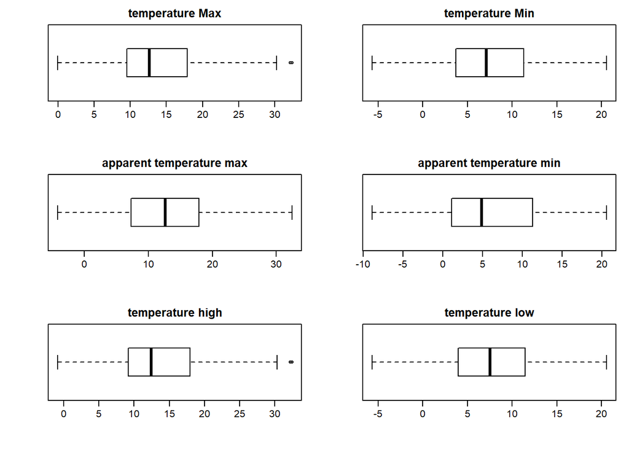

```
## numeric(0)
```

```r
boxplot(weather_daily$temperatureLow, main="temperature low",horizontal = TRUE)$out
```

```r
boxplot(weather_daily$apparentTemperatureHigh, main="apparent temperature high",horizontal = TRUE)$out
```

```
## numeric(0)
```

```r
boxplot(weather_daily$apparentTemperatureLow, main="apparent temperature low",horizontal = TRUE)$out
```

```
## numeric(0)
```

```r
boxplot(weather_daily$dewPoint, main="dew point",horizontal = TRUE)$out
```

```
## [1] -7.84
```

```r
boxplot(weather_daily$cloudCover, main="cloud cover",horizontal = TRUE)$out
```

```
## [1] 0.98 1.00 1.00
```

```r
boxplot(weather_daily$windBearing, main="wind Bearing",horizontal = TRUE)$out
```

```
## numeric(0)
```

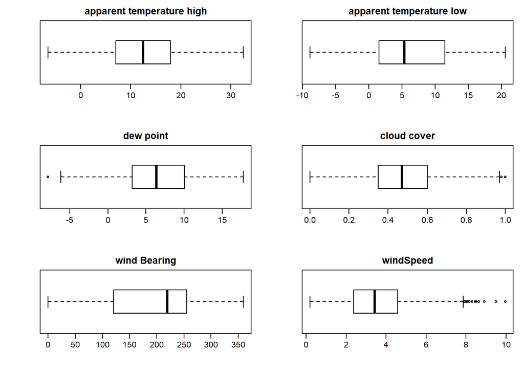

```
##  [1] 9.49 8.01 7.98 8.47 8.64 7.92 8.91 8.12 8.17 8.48 8.05 8.30 8.53 9.96
```

```r
boxplot(weather_daily$windSpeed, main="windSpeed",horizontal = TRUE)$out
```

```r
boxplot(weather_daily$pressure, main="pressure",horizontal = TRUE)$out
```

```
##  [1] 984.05 979.63 982.22 985.82 984.66 979.52 985.33 982.20 984.71 979.25
```

```r
boxplot(weather_daily$visibility, main="visibility",horizontal = TRUE)$out
```

```
##  [1] 3.30 3.69 2.64 4.31 2.82 6.41 5.89 5.39 4.60 4.83 5.15 3.35 3.19 4.18
## [15] 3.20 5.62 2.90 4.91 1.48 4.06 6.37 6.12 6.28 6.18 1.82 5.70 6.08 6.18
## [29] 6.08 3.28 2.45 6.49 4.76 3.48 5.05 4.39 5.70 3.14 6.10 3.75 6.41 5.39
## [43] 5.91 3.48 2.78 5.21 6.07 5.58 5.10 1.93 4.36 6.31 6.34 3.48 4.44 5.73
## [57] 4.12 6.41 3.73 5.68 5.50 4.49 4.91 6.53 4.15 6.36 6.24
```

```r
boxplot(weather_daily$uvIndex, main="uv index",horizontal = TRUE)$out
```

```
## numeric(0)
```

```r
boxplot(weather_daily$moonPhase, main="moonphase",horizontal = TRUE)$out
```

```
## numeric(0)
```

```r
#no hi ha cap valor que sobresurti del normal.
```

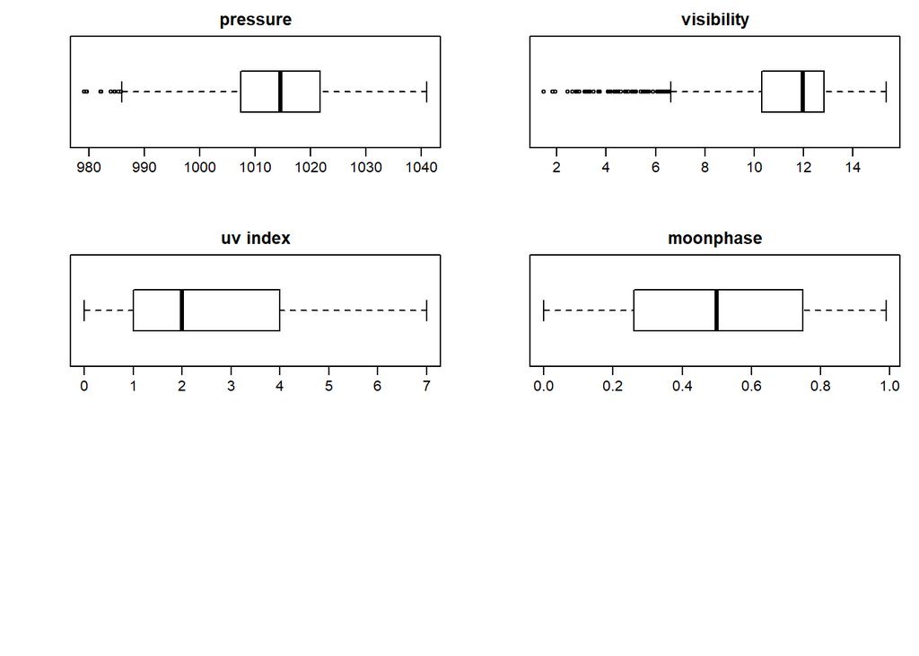

```r
#Mirem si cont? valors buits
colSums(is.na(weather_daily))
```

```
##              temperatureMax          temperatureMaxTime
##                           0                           0
##                 windBearing                        icon
##                           0                           0
##                    dewPoint          temperatureMinTime
##                           0                           0
##                  cloudCover                   windSpeed
##                           1                           0
##                    pressure  apparentTemperatureMinTime
##                           0                           0
##     apparentTemperatureHigh                  precipType
##                           0                           0
##                  visibility                    humidity
##                           0                           0
## apparentTemperatureHighTime      apparentTemperatureLow
##                           0                           0
##      apparentTemperatureMax                     uvIndex
##                           0                           1
##                        time                  sunsetTime
##                           0                           0
##              temperatureLow              temperatureMin
##                           0                           0
##             temperatureHigh                 sunriseTime
##                           0                           0
##         temperatureHighTime                 uvIndexTime
##                           0                           0
##                     summary          temperatureLowTime
##                           0                           0
##      apparentTemperatureMin  apparentTemperatureMaxTime
##                           0                           0
##  apparentTemperatureLowTime                   moonPhase
##                           0                           0
```

```r
colSums(weather_daily=="")
```

```
##              temperatureMax          temperatureMaxTime
##                           0                           0
##                 windBearing                        icon
##                           0                           0
##                    dewPoint          temperatureMinTime
##                           0                           0
##                  cloudCover                   windSpeed
##                          NA                           0
##                    pressure  apparentTemperatureMinTime
##                           0                           0
##     apparentTemperatureHigh                  precipType
##                           0                           0
##                  visibility                    humidity
##                           0                           0
## apparentTemperatureHighTime      apparentTemperatureLow
##                           0                           0
##      apparentTemperatureMax                     uvIndex
##                           0                          NA
##                        time                  sunsetTime
##                           0                           0
##              temperatureLow              temperatureMin
##                           0                           0
##             temperatureHigh                 sunriseTime
##                           0                           0
##         temperatureHighTime                 uvIndexTime
##                           0                           1
##                     summary          temperatureLowTime
##                           0                           0
##      apparentTemperatureMin  apparentTemperatureMaxTime
##                           0                           0
##  apparentTemperatureLowTime                   moonPhase
##                           0                           0
```

Passem a comprovar si conté valors buits i veiem que conté valors buits a les variables cloudCover, uvIndex i uvIndexTime .

```r
weather_daily[is.na(weather_daily$cloudCover),]
```

```
##     temperatureMax  temperatureMaxTime windBearing icon dewPoint
## 847          11.34 2014-01-01 20:00:00         187 wind     6.78
##      temperatureMinTime cloudCover windSpeed pressure
## 847 2014-01-01 02:00:00         NA       7.2   993.32
##     apparentTemperatureMinTime apparentTemperatureHigh precipType
## 847        2014-01-01 02:00:00                   10.83       rain
##     visibility humidity apparentTemperatureHighTime apparentTemperatureLow
## 847       9.95     0.86         2014-01-01 19:00:00                   3.36
##     apparentTemperatureMax uvIndex                time          sunsetTime
## 847                  11.34      NA 2014-01-01 00:00:00 2014-01-01 16:02:49
##     temperatureLow temperatureMin temperatureHigh         sunriseTime
## 847           6.54           6.59           10.83 2014-01-01 08:07:22
##     temperatureHighTime uvIndexTime               summary
## 847 2014-01-01 19:00:00             Breezy until evening.
##      temperatureLowTime apparentTemperatureMin apparentTemperatureMaxTime
## 847 2014-01-02 08:00:00                   3.18        2014-01-01 20:00:00
##     apparentTemperatureLowTime moonPhase
## 847        2014-01-02 08:00:00      0.01
```

```r
weather_daily[is.na(weather_daily$uvIndex),]
```

```
##     temperatureMax  temperatureMaxTime windBearing icon dewPoint
## 847          11.34 2014-01-01 20:00:00         187 wind     6.78
##      temperatureMinTime cloudCover windSpeed pressure
## 847 2014-01-01 02:00:00         NA       7.2   993.32
##     apparentTemperatureMinTime apparentTemperatureHigh precipType
## 847        2014-01-01 02:00:00                   10.83       rain
##     visibility humidity apparentTemperatureHighTime apparentTemperatureLow
## 847       9.95     0.86         2014-01-01 19:00:00                   3.36
##     apparentTemperatureMax uvIndex                time          sunsetTime
## 847                  11.34      NA 2014-01-01 00:00:00 2014-01-01 16:02:49
##     temperatureLow temperatureMin temperatureHigh         sunriseTime
## 847           6.54           6.59           10.83 2014-01-01 08:07:22
##     temperatureHighTime uvIndexTime               summary
## 847 2014-01-01 19:00:00             Breezy until evening.
##      temperatureLowTime apparentTemperatureMin apparentTemperatureMaxTime
## 847 2014-01-02 08:00:00                   3.18        2014-01-01 20:00:00
##     apparentTemperatureLowTime moonPhase
## 847        2014-01-02 08:00:00      0.01
```

```r
weather_daily[weather_daily$uvIndexTime == "",]
```

```
##     temperatureMax  temperatureMaxTime windBearing icon dewPoint
## 847          11.34 2014-01-01 20:00:00         187 wind     6.78
##      temperatureMinTime cloudCover windSpeed pressure
## 847 2014-01-01 02:00:00         NA       7.2   993.32
##     apparentTemperatureMinTime apparentTemperatureHigh precipType
## 847        2014-01-01 02:00:00                   10.83       rain
##     visibility humidity apparentTemperatureHighTime apparentTemperatureLow
## 847       9.95     0.86         2014-01-01 19:00:00                   3.36
##     apparentTemperatureMax uvIndex                time          sunsetTime
## 847                  11.34      NA 2014-01-01 00:00:00 2014-01-01 16:02:49
##     temperatureLow temperatureMin temperatureHigh         sunriseTime
## 847           6.54           6.59           10.83 2014-01-01 08:07:22
##     temperatureHighTime uvIndexTime               summary
## 847 2014-01-01 19:00:00             Breezy until evening.
##      temperatureLowTime apparentTemperatureMin apparentTemperatureMaxTime
## 847 2014-01-02 08:00:00                   3.18        2014-01-01 20:00:00
##     apparentTemperatureLowTime moonPhase
## 847        2014-01-02 08:00:00      0.01
```

Veiem que el valor buit es tracta de la mateixa l?nia

```r
library(dplyr)
```

```r
#seleccionem atributs numerics sense NA per veure'n la correlació:

weather_daily_num<- select(weather_daily[!is.na(weather_daily$uvIndex),], temperatureMax, temperatureMin, temperatureHigh,temperatureLow,apparentTemperatureMax, apparentTemperatureMin, apparentTemperatureLow, apparentTemperatureHigh, windBearing, dewPoint, cloudCover,windSpeed , pressure,  visibility, humidity,   uvIndex,  moonPhase )


cor(weather_daily_num$cloudCover,weather_daily_num)
```

```
##      temperatureMax temperatureMin temperatureHigh temperatureLow
## [1,]     -0.3325842    -0.04275557       -0.335188    -0.08822635
##      apparentTemperatureMax apparentTemperatureMin apparentTemperatureLow
## [1,]              -0.306005            -0.08446808             -0.1212161
##      apparentTemperatureHigh windBearing     dewPoint cloudCover windSpeed
## [1,]              -0.3111222 -0.08374044 -0.003381655          1 0.1652375
##        pressure visibility  humidity   uvIndex   moonPhase
## [1,] -0.1015241 -0.3166734 0.4928097 -0.254932 -0.05454218
```

```r
cor(weather_daily_num$uvIndex,weather_daily_num)
```

```
##      temperatureMax temperatureMin temperatureHigh temperatureLow
## [1,]      0.6892058      0.5821429       0.6944033      0.5656305
##      apparentTemperatureMax apparentTemperatureMin apparentTemperatureLow
## [1,]              0.6696491              0.6039212              0.5883417
##      apparentTemperatureHigh windBearing  dewPoint cloudCover  windSpeed
## [1,]               0.6744025 -0.07473278 0.4646951  -0.254932 -0.1387633
##        pressure visibility   humidity uvIndex  moonPhase
## [1,] 0.09778869  0.2506189 -0.5393162       1 0.01794562
```

```r
cor (weather_daily_num$temperatureHigh,weather_daily_num)
```

```
##      temperatureMax temperatureMin temperatureHigh temperatureLow
## [1,]      0.9978441      0.8873585               1      0.8717393
##      apparentTemperatureMax apparentTemperatureMin apparentTemperatureLow
## [1,]               0.987315              0.9045109              0.8871937
##      apparentTemperatureHigh windBearing  dewPoint cloudCover  windSpeed
## [1,]               0.9891972  0.06172454 0.8514681  -0.335188 -0.1554074
##       pressure visibility   humidity   uvIndex   moonPhase
## [1,] 0.1338041  0.2456631 -0.4048027 0.6944033 0.003986885
```

```r
cor (weather_daily_num$windBearing,weather_daily_num)
```

```
##      temperatureMax temperatureMin temperatureHigh temperatureLow
## [1,]     0.06622604     0.06537021      0.06172454     0.04883373
##      apparentTemperatureMax apparentTemperatureMin apparentTemperatureLow
## [1,]             0.07499284             0.05212448              0.0440364
##      apparentTemperatureHigh windBearing   dewPoint  cloudCover  windSpeed
## [1,]              0.07309009           1 0.08770354 -0.08374044 0.07855813
##        pressure visibility    humidity     uvIndex  moonPhase
## [1,] -0.0306246  0.2761572 0.001558392 -0.07473278 0.02319574
```

uvIndex també es podria predir amb un arbre ( sent factor)

```r
X<- select(weather_daily[!is.na(weather_daily$uvIndex),], -temperatureMaxTime, -temperatureMinTime, -temperatureHighTime,-temperatureLowTime,-apparentTemperatureMaxTime, -apparentTemperatureMinTime, -apparentTemperatureLowTime, -apparentTemperatureHighTime, -uvIndexTime, -time, - sunsetTime, - sunriseTime, -uvIndex, -temperatureHigh,-temperatureLow,-apparentTemperatureMax, -apparentTemperatureMin, -apparentTemperatureLow, -apparentTemperatureHigh ) #Fem dataset sense les dates i sense uvIndex


y<-weather_daily$uvIndex[!is.na(weather_daily$uvIndex)]
y<- as.factor(y)

X_train<-X[1:588,]
X_test<-X[589:881,]

y_train<- y[1:588]
y_test<- y[589:881]
```

```r
#Regressió lineal múltiple per predir els valors de CloudCover i uvIndex.
#Cloudcover
model_prediccio_cloudCover<-lm(cloudCover~ humidity + temperatureHigh + visibility  + windSpeed + pressure + windBearing + moonPhase, data=weather_daily[!is.na(weather_daily$cloudCover),])

summary(model_prediccio_cloudCover)
```

```
##
## Call:
## lm(formula = cloudCover ~ humidity + temperatureHigh + visibility +
##     windSpeed + pressure + windBearing + moonPhase, data = weather_daily[!is.na(weather_daily$cloudCover),
##     ])
##
## Residuals:
##      Min       1Q   Median       3Q      Max
## -0.63556 -0.09847  0.00531  0.10426  0.59161
##
## Coefficients:
##                   Estimate Std. Error t value Pr(>|t|)
## (Intercept)     -1.793e+00  5.862e-01  -3.059  0.00229 **
## humidity         8.873e-01  7.934e-02  11.184  < 2e-16 ***
## temperatureHigh -3.419e-03  9.707e-04  -3.522  0.00045 ***
## visibility      -6.208e-03  3.048e-03  -2.037  0.04197 *
## windSpeed        2.648e-02  3.643e-03   7.268 8.09e-13 ***
## pressure         1.620e-03  5.466e-04   2.964  0.00312 **
## windBearing     -1.516e-04  6.471e-05  -2.343  0.01938 *
## moonPhase       -3.047e-02  1.895e-02  -1.608  0.10822
## ---
## Signif. codes:  0 '***' 0.001 '**' 0.01 '*' 0.05 '.' 0.1 ' ' 1
##
## Residual standard error: 0.1608 on 873 degrees of freedom
## Multiple R-squared:  0.3148, Adjusted R-squared:  0.3093
## F-statistic:  57.3 on 7 and 873 DF,  p-value: < 2.2e-16
```

```r
#uvindex
model_prediccio_uvIndex<- lm(uvIndex~ temperatureHigh + humidity + visibility  + windSpeed + pressure + windBearing + moonPhase ,data=weather_daily[!is.na(weather_daily$cloudCover),] )
summary(model_prediccio_uvIndex)
```

```
##
## Call:
## lm(formula = uvIndex ~ temperatureHigh + humidity + visibility +
##     windSpeed + pressure + windBearing + moonPhase, data = weather_daily[!is.na(weather_daily$cloudCover),
##     ])
##
## Residuals:
##     Min      1Q  Median      3Q     Max
## -3.0683 -0.8318 -0.2068  0.6933  3.4503
##
## Coefficients:
##                   Estimate Std. Error t value Pr(>|t|)
## (Intercept)     24.0457036  4.3113137   5.577 3.26e-08 ***
## temperatureHigh  0.1650638  0.0071390  23.121  < 2e-16 ***
## humidity        -7.2153280  0.5835218 -12.365  < 2e-16 ***
## visibility      -0.0459029  0.0224157  -2.048 0.040878 *
## windSpeed       -0.0875657  0.0267902  -3.269 0.001123 **
## pressure        -0.0167383  0.0040199  -4.164 3.44e-05 ***
## windBearing     -0.0018267  0.0004759  -3.838 0.000133 ***
## moonPhase        0.1205742  0.1393539   0.865 0.387146
## ---
## Signif. codes:  0 '***' 0.001 '**' 0.01 '*' 0.05 '.' 0.1 ' ' 1
##
## Residual standard error: 1.183 on 873 degrees of freedom
## Multiple R-squared:  0.5869, Adjusted R-squared:  0.5836
## F-statistic: 177.2 on 7 and 873 DF,  p-value: < 2.2e-16
```

```r
#Predim valors
predit_cloudCover<-predict(model_prediccio_cloudCover,weather_daily[is.na(weather_daily$cloudCover),])

predit_uvIndex<- round(predict(model_prediccio_uvIndex,weather_daily[is.na(weather_daily$uvIndex),] ))

predit_cloudCover
```

```
##       847
## 0.6423095
```

```r
predit_uvIndex
```

```
## 847
##   2
```

```r
#Assignem els valors predits a les corresponents variables NA

weather_daily$cloudCover[is.na(weather_daily$cloudCover)]<- predit_cloudCover

weather_daily$uvIndex[is.na(weather_daily$uvIndex)]<- predit_uvIndex
```

Comprovem

```r
colSums(is.na(weather_daily))
```

```
##              temperatureMax          temperatureMaxTime
##                           0                           0
##                 windBearing                        icon
##                           0                           0
##                    dewPoint          temperatureMinTime
##                           0                           0
##                  cloudCover                   windSpeed
##                           0                           0
##                    pressure  apparentTemperatureMinTime
##                           0                           0
##     apparentTemperatureHigh                  precipType
##                           0                           0
##                  visibility                    humidity
##                           0                           0
## apparentTemperatureHighTime      apparentTemperatureLow
##                           0                           0
##      apparentTemperatureMax                     uvIndex
##                           0                           0
##                        time                  sunsetTime
##                           0                           0
##              temperatureLow              temperatureMin
##                           0                           0
##             temperatureHigh                 sunriseTime
##                           0                           0
##         temperatureHighTime                 uvIndexTime
##                           0                           0
##                     summary          temperatureLowTime
##                           0                           0
##      apparentTemperatureMin  apparentTemperatureMaxTime
##                           0                           0
##  apparentTemperatureLowTime                   moonPhase
##                           0                           0
```

Abans de tractar els nuls de uvindextime, transformem algunes variables

```r
#Convertim la variable temperatureMaxTime en format timedate(data i hora) enlloc de factor
weather_daily$temperatureMaxTime<-as.timeDate(weather_daily$temperatureMaxTime)
#Creem una variable per guardar tant sols l'hora (sense la data)
weather_daily$temperatureMaxHour<-hour(weather_daily$temperatureMaxTime)

#Fem el mateix amb les altres variables:

#time
weather_daily$time<-as.timeDate(weather_daily$time)
weather_daily$date<-as.Date(weather_daily$time)


#temperatureMinTime
weather_daily$temperatureMinTime<-as.timeDate(weather_daily$temperatureMinTime)
weather_daily$temperatureMinHour<-hour(weather_daily$temperatureMinTime)

#apparentTemperatureMinTime
weather_daily$apparentTemperatureMinTime<-as.timeDate(weather_daily$apparentTemperatureMinTime)
weather_daily$apparentTemperatureMinHour<-hour(weather_daily$apparentTemperatureMinTime)

#apparentTemperatureMaxTime

weather_daily$apparentTemperatureMaxTime<-as.timeDate(weather_daily$apparentTemperatureMaxTime)
weather_daily$apparentTemperatureMaxHour<-hour(weather_daily$apparentTemperatureMaxTime)

#apparentTemperatureHighTime
weather_daily$apparentTemperatureHighTime<-as.timeDate(weather_daily$apparentTemperatureHighTime)
weather_daily$apparentTemperatureHighHour<-hour(weather_daily$apparentTemperatureHighTime)

#apparentTemperatureLowTime
weather_daily$apparentTemperatureLowTime<-as.timeDate(weather_daily$apparentTemperatureLowTime)
weather_daily$apparentTemperatureLowHour<-hour(weather_daily$apparentTemperatureLowTime)

#sunsetTime
weather_daily$sunsetTime<-as.timeDate(weather_daily$sunsetTime)
weather_daily$sunsetTimeHour<-hour(weather_daily$sunsetTime)

#sunriseTime
weather_daily$sunriseTime<-as.timeDate(weather_daily$sunriseTime)
weather_daily$sunriseTimeHour<-hour(weather_daily$sunriseTime)

#temperatureHighTime
weather_daily$temperatureHighTime<-as.timeDate(weather_daily$temperatureHighTime)
weather_daily$temperatureHighHour<-hour(weather_daily$temperatureHighTime)

#temperatureLowTime
weather_daily$temperatureLowTime<-as.timeDate(weather_daily$temperatureLowTime)
weather_daily$temperatureLowHour<-hour(weather_daily$temperatureLowTime)

#uvIndexTime
weather_daily$uvIndexTime<-as.timeDate(weather_daily$uvIndexTime)
weather_daily$uvIndexHour<-hour(weather_daily$uvIndexTime)





#Com que cada fila (amb totes les variables) ?s el mateix dia, llavors es pot simplificar i crear una ?nica variable amb la data i tamb? crear unes "subvariables" per l'any i mes.
#Creem variables Data, Any, Mes
weather_daily$year<-year(weather_daily$date)
weather_daily$month<-month(weather_daily$date)
weather_daily$weekday<-wday(weather_daily$date, label=FALSE, week_start = 1)#Week_start=-1 means Monday.  7 means sunday.

#Comprovem les variables que hem creat:
str(weather_daily)
```

```
## 'data.frame':    882 obs. of  47 variables:
##  $ temperatureMax             : num  11.96 8.59 10.33 8.07 8.22 ...
##  $ temperatureMaxTime         :Formal class 'timeDate' [package "timeDate"] with 3 slots
##   .. ..@ Data     : POSIXct, format: "2011-11-11 23:00:00" ...
##   .. ..@ format   : chr "%Y-%m-%d %H:%M:%S"
##   .. ..@ FinCenter: chr "GMT"
##  $ windBearing                : int  123 198 225 232 252 234 117 117 221 115 ...
##  $ icon                       : Factor w/ 6 levels "clear-day","cloudy",..: 3 4 4 6 5 6 3 3 6 3 ...
##  $ dewPoint                   : num  9.4 4.49 5.47 3.69 2.79 2.41 8.12 5.58 4.1 6.62 ...
##  $ temperatureMinTime         :Formal class 'timeDate' [package "timeDate"] with 3 slots
##   .. ..@ Data     : POSIXct, format: "2011-11-11 07:00:00" ...
##   .. ..@ format   : chr "%Y-%m-%d %H:%M:%S"
##   .. ..@ FinCenter: chr "GMT"
##  $ cloudCover                 : num  0.79 0.56 0.85 0.32 0.37 0.42 0.26 0.81 0.38 0.41 ...
##  $ windSpeed                  : num  3.88 3.94 3.54 3 4.46 4.71 2.37 2.36 5.02 1.24 ...
##  $ pressure                   : num  1016 1008 1033 1012 1028 ...
##  $ apparentTemperatureMinTime :Formal class 'timeDate' [package "timeDate"] with 3 slots
##   .. ..@ Data     : POSIXct, format: "2011-11-11 07:00:00" ...
##   .. ..@ format   : chr "%Y-%m-%d %H:%M:%S"
##   .. ..@ FinCenter: chr "GMT"
##  $ apparentTemperatureHigh    : num  10.87 5.62 10.33 5.33 5.02 ...
##  $ precipType                 : Factor w/ 2 levels "rain","snow": 1 1 1 1 1 1 1 1 1 1 ...
##  $ visibility                 : num  3.3 12.1 13.4 11.9 13.2 ...
##  $ humidity                   : num  0.95 0.88 0.74 0.87 0.8 0.77 0.92 0.93 0.84 0.96 ...
##  $ apparentTemperatureHighTime:Formal class 'timeDate' [package "timeDate"] with 3 slots
##   .. ..@ Data     : POSIXct, format: "2011-11-11 19:00:00" ...
##   .. ..@ format   : chr "%Y-%m-%d %H:%M:%S"
##   .. ..@ FinCenter: chr "GMT"
##  $ apparentTemperatureLow     : num  10.87 -0.64 5.52 3.26 4.37 ...
##  $ apparentTemperatureMax     : num  11.96 5.72 10.33 5.33 5.32 ...
##  $ uvIndex                    : num  1 1 0 1 1 1 1 1 1 1 ...
##  $ time                       :Formal class 'timeDate' [package "timeDate"] with 3 slots
##   .. ..@ Data     : POSIXct, format: "2011-11-11 00:00:00" ...
##   .. ..@ format   : chr "%Y-%m-%d %H:%M:%S"
##   .. ..@ FinCenter: chr "GMT"
##  $ sunsetTime                 :Formal class 'timeDate' [package "timeDate"] with 3 slots
##   .. ..@ Data     : POSIXct, format: "2011-11-11 16:19:21" ...
##   .. ..@ format   : chr "%Y-%m-%d %H:%M:%S"
##   .. ..@ FinCenter: chr "GMT"
##  $ temperatureLow             : num  10.87 3.09 8.03 6.33 7.45 ...
```

[output cut: 29 more lines]

```
##  $ temperatureMaxHour         : int  23 14 2 23 23 14 14 23 23 14 ...
##  $ date                       : Date, format: "2011-11-11" "2011-12-11" ...
##  $ temperatureMinHour         : int  7 1 23 7 7 0 23 7 7 8 ...
##  $ apparentTemperatureMinHour : int  7 2 22 7 7 0 8 4 8 8 ...
##  $ apparentTemperatureMaxHour : int  23 20 2 12 23 21 14 23 23 15 ...
##  $ apparentTemperatureHighHour: int  19 19 14 12 15 14 14 14 16 15 ...
##  $ apparentTemperatureLowHour : int  19 8 0 19 20 8 8 19 8 1 ...
##  $ sunsetTimeHour             : int  16 15 15 15 15 15 16 16 15 16 ...
##  $ sunriseTimeHour            : int  7 7 8 7 8 8 7 7 7 7 ...
##  $ temperatureHighHour        : int  19 14 14 12 15 14 14 14 19 14 ...
##  $ temperatureLowHour         : int  19 7 23 19 19 8 8 19 8 2 ...
##  $ uvIndexHour                : int  11 12 0 10 13 11 10 11 11 10 ...
##  $ year                       : num  2011 2011 2011 2011 2011 ...
##  $ month                      : num  11 12 12 12 12 12 11 11 12 11 ...
##  $ weekday                    : num  5 7 2 5 6 4 6 3 1 7 ...
```

Podem eliminar totes les variables “time”

```r
weather_daily<- select(weather_daily, -temperatureMaxTime, -temperatureMinTime, -temperatureHighTime,-temperatureLowTime,-apparentTemperatureMaxTime, -apparentTemperatureMinTime, -apparentTemperatureLowTime, -apparentTemperatureHighTime, -uvIndexTime, -time, - sunsetTime, - sunriseTime)
```

```r
str(weather_daily)
```

```
## 'data.frame':    882 obs. of  35 variables:
##  $ temperatureMax             : num  11.96 8.59 10.33 8.07 8.22 ...
##  $ windBearing                : int  123 198 225 232 252 234 117 117 221 115 ...
##  $ icon                       : Factor w/ 6 levels "clear-day","cloudy",..: 3 4 4 6 5 6 3 3 6 3 ...
##  $ dewPoint                   : num  9.4 4.49 5.47 3.69 2.79 2.41 8.12 5.58 4.1 6.62 ...
##  $ cloudCover                 : num  0.79 0.56 0.85 0.32 0.37 0.42 0.26 0.81 0.38 0.41 ...
##  $ windSpeed                  : num  3.88 3.94 3.54 3 4.46 4.71 2.37 2.36 5.02 1.24 ...
##  $ pressure                   : num  1016 1008 1033 1012 1028 ...
##  $ apparentTemperatureHigh    : num  10.87 5.62 10.33 5.33 5.02 ...
##  $ precipType                 : Factor w/ 2 levels "rain","snow": 1 1 1 1 1 1 1 1 1 1 ...
##  $ visibility                 : num  3.3 12.1 13.4 11.9 13.2 ...
##  $ humidity                   : num  0.95 0.88 0.74 0.87 0.8 0.77 0.92 0.93 0.84 0.96 ...
##  $ apparentTemperatureLow     : num  10.87 -0.64 5.52 3.26 4.37 ...
##  $ apparentTemperatureMax     : num  11.96 5.72 10.33 5.33 5.32 ...
##  $ uvIndex                    : num  1 1 0 1 1 1 1 1 1 1 ...
```

[output cut: 21 more lines]

```r
#Ordenem les dades de weather_daily per data
weather_daily<-weather_daily[order(weather_daily$date),]
```

Assignem valor a l’hora NA de uvindexHour

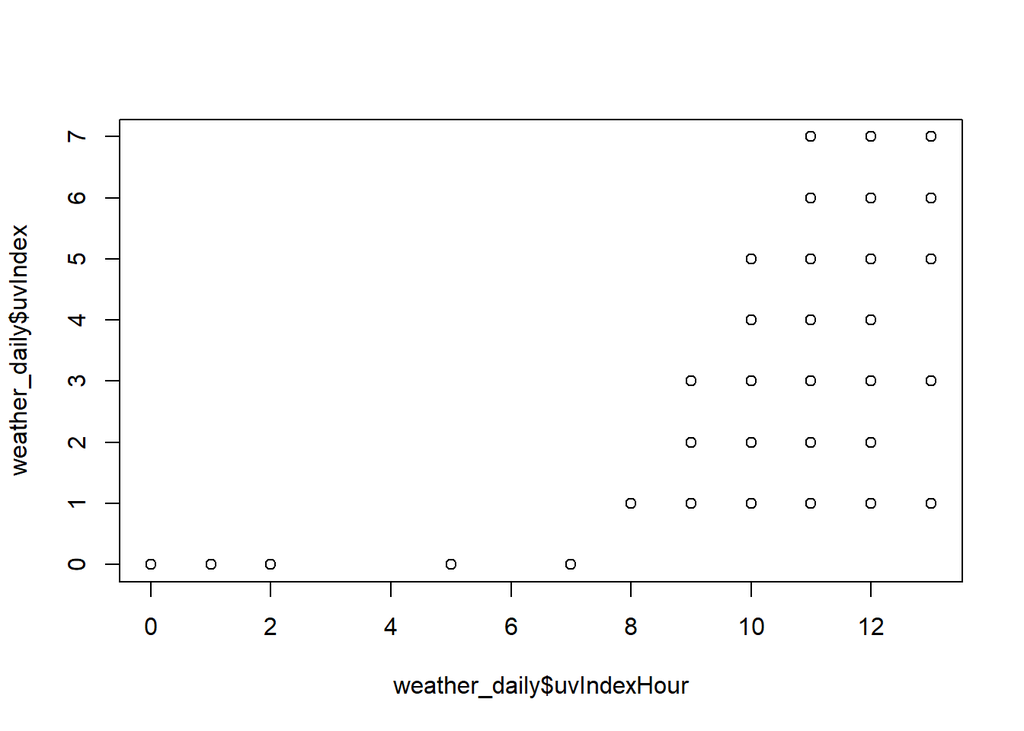

```r
plot(weather_daily$uvIndexHour, weather_daily$uvIndex)
```

Veiem que els uvIndex=2 s’han produit a les hores 9,10,11,12.

```r
weather_daily$uvIndexHour[is.na(weather_daily$uvIndexHour)]<- 11
```

## Gràfics

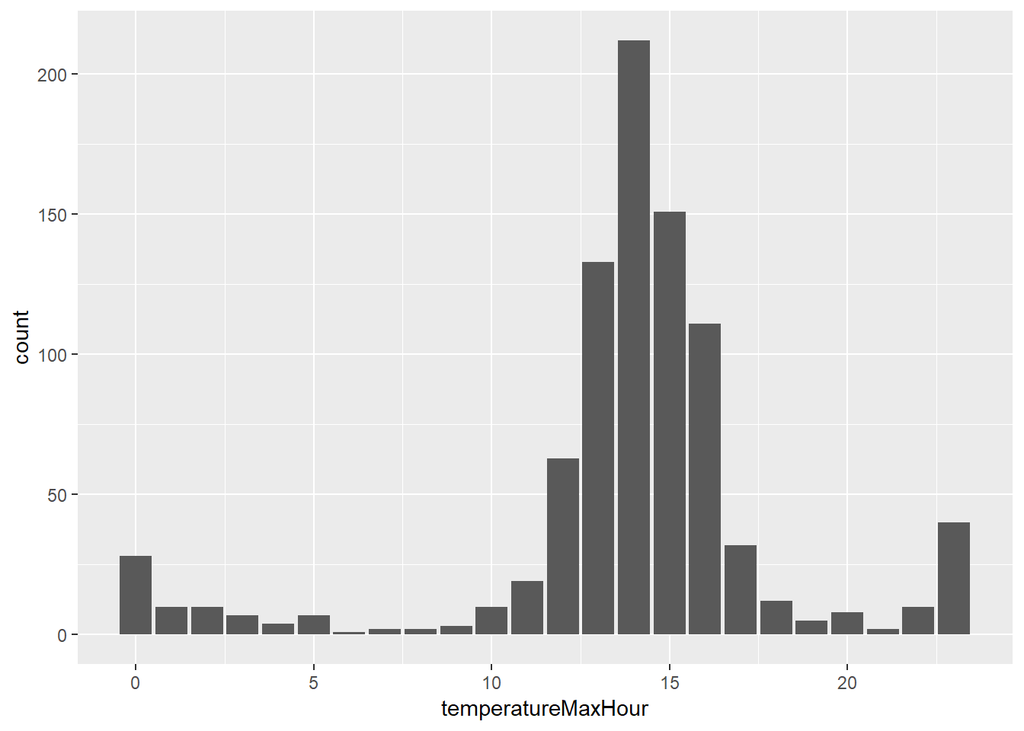

```r
ggplot(weather_daily,aes(x=temperatureMaxHour,fill=temperatureMax))+geom_bar()
```

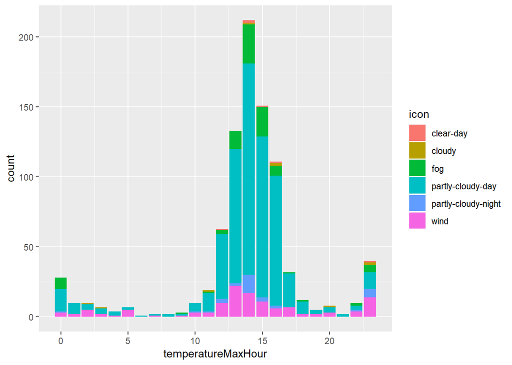

```r
ggplot(weather_daily,aes(x=temperatureMaxHour,fill=icon))+geom_bar()
```

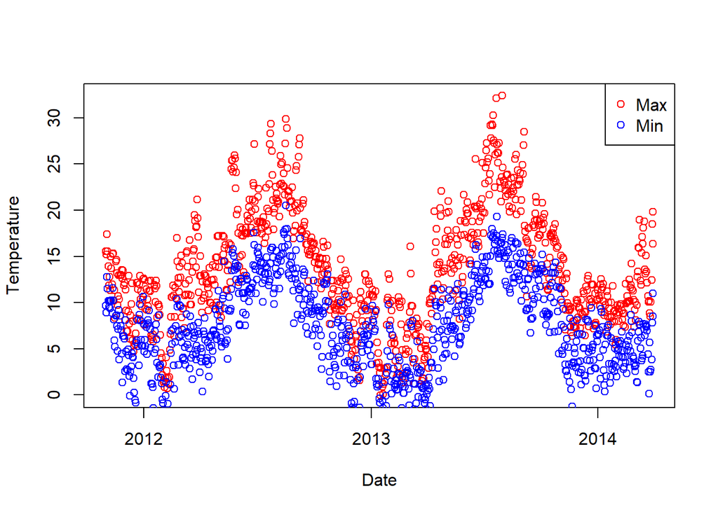

```r
plot(weather_daily$date, weather_daily$temperatureMax , type="p", col="red", ylab="Temperature", xlab="Date")
points(weather_daily$date, weather_daily$temperatureMin , col="blue")
legend("topright",legend=c("Max", "Min"), col=c("red", "blue"), pch=c(1,1))
```

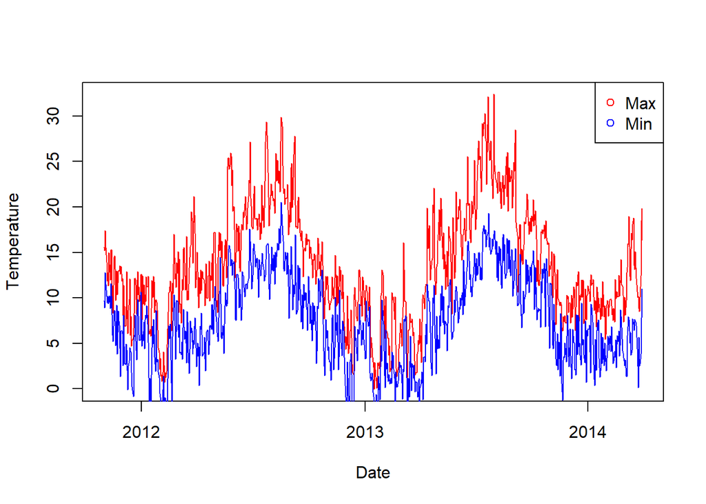

```r
plot(weather_daily$date, weather_daily$temperatureMax , type="l", col="red", ylab="Temperature", xlab="Date")
lines(weather_daily$date, weather_daily$temperatureMin , col="blue")
legend("topright",legend=c("Max", "Min"), col=c("red", "blue"), pch=c(1,1))
```

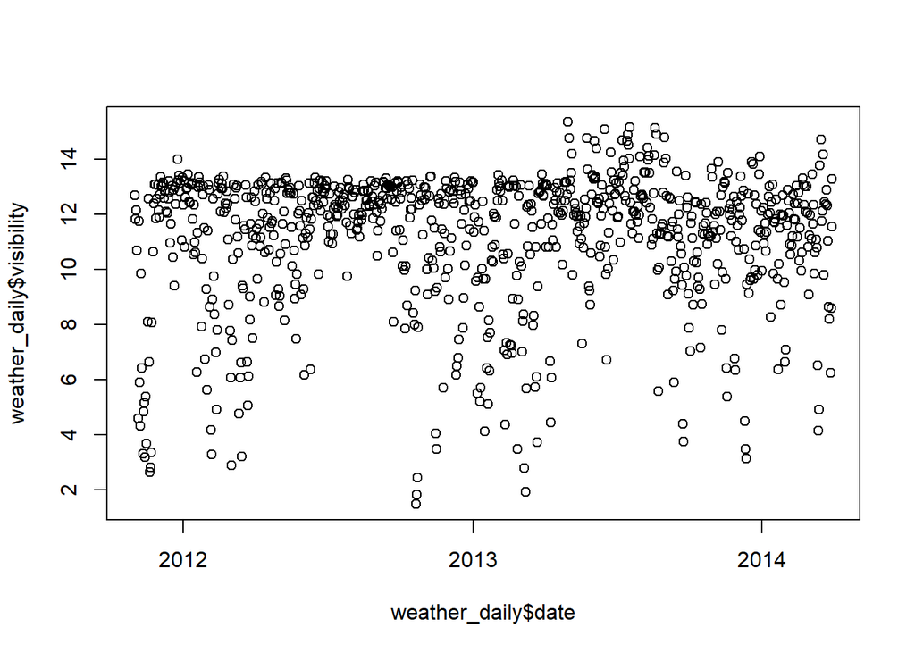

```r
plot(weather_daily$date, weather_daily$visibility , type="p")
```

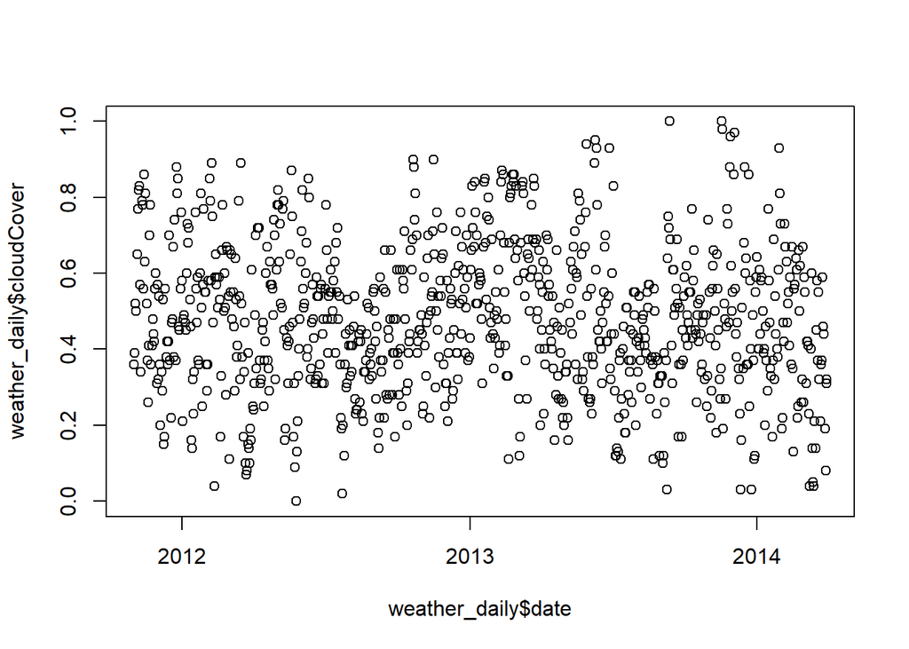

```r
plot(weather_daily$date, weather_daily$cloudCover , type="p")
```

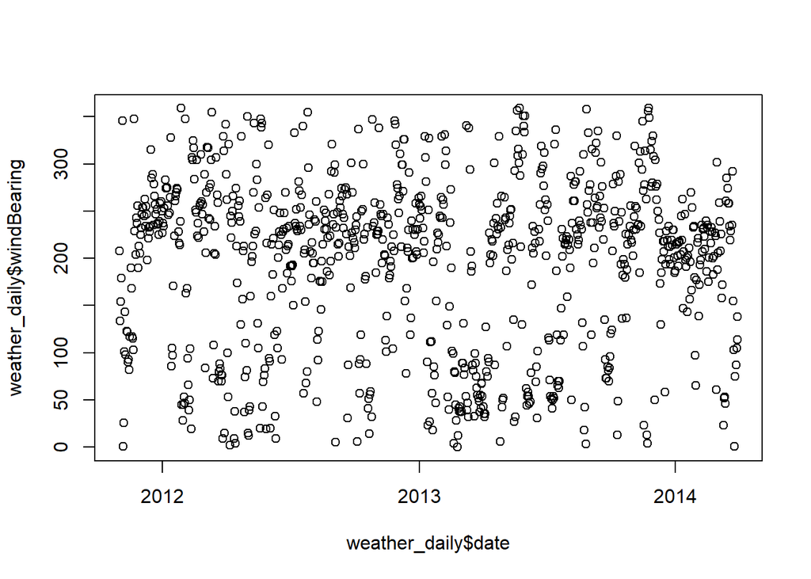

```r
plot(weather_daily$date, weather_daily$windBearing , type="p")
```

# UK bank holidays

```r
#Carreguem arxiu de dades
uk_bank_holidays <-read.csv(file="dades/8uk_bank_holidays.csv", header=TRUE, sep=",", stringsAsFactors = FALSE)
```

```r
#Resum dades

#Dimensi?
dim(uk_bank_holidays)
```

```
## [1] 25  2
```

```r
# Resum
summary(uk_bank_holidays)
```

```
##  Bank.holidays          Type
##  Length:25          Length:25
##  Class :character   Class :character
##  Mode  :character   Mode  :character
```

```r
# Tipus de dades
str(uk_bank_holidays)
```

```
## 'data.frame':    25 obs. of  2 variables:
##  $ Bank.holidays: chr  "2012-12-26" "2012-12-25" "2012-08-27" "2012-05-06" ...
##  $ Type         : chr  "Boxing Day" "Christmas Day" "Summer bank holiday" "Queen?s Diamond Jubilee (extra bank holiday)" ...
```

```r
summary(uk_bank_holidays$Type)
```

```
##    Length     Class      Mode
##        25 character character
```

Veiem que dos noms estan repetits:  
New Years Day i New Year?s Day (substitute day) Spring bank holiday i Spring bank holiday (substitute day)

Els unifiquem

```r
uk_bank_holidays$Type[uk_bank_holidays$Type=="Spring bank holiday (substitute day)"] <- "Spring bank holiday"

uk_bank_holidays$Type[uk_bank_holidays$Type=="Spring bank holiday (substitute day)"] <- "Spring bank holiday"

uk_bank_holidays$Type[uk_bank_holidays$Type== "New Year?s Day (substitute day)"] <- "New Years Day"
uk_bank_holidays$Type[uk_bank_holidays$Type== "New Year?s Day"] <- "New Years Day"
```

Factoritzem la variable Type i convertim a data la variable Bank.holidays

```r
uk_bank_holidays$Bank.holidays<- as.Date(uk_bank_holidays$Bank.holidays)

uk_bank_holidays$Type<- as.factor(uk_bank_holidays$Type)
```

Valors buits

```r
#Mirem si cont? valors buits
colSums(is.na(uk_bank_holidays))
```

```
## Bank.holidays          Type
##             0             0
```

```r
#Convertim dates de factor a date
uk_bank_holidays$Bank.holidays<-as.Date(uk_bank_holidays$Bank.holidays)

#Renombrem columnes
names(uk_bank_holidays)<-c("day", "holidayType")
```

# Daily dataset csv (resum)

```r
#Carreguem arxiu de dades
daily_dataset_csv <-read.csv(file="dades/3daily_dataset_csv.csv", header=TRUE, sep="," , stringsAsFactors = FALSE)
```

```r
#Resum dades

#Dimensi?
dim(daily_dataset_csv)
```

```
## [1] 3510433       9
```

```r
# Resum
summary(daily_dataset_csv)
```

```
##     LCLid               day            energy_median     energy_mean
##  Length:3510433     Length:3510433     Min.   :0.0000   Min.   :0.00000
##  Class :character   Class :character   1st Qu.:0.0670   1st Qu.:0.09808
##  Mode  :character   Mode  :character   Median :0.1145   Median :0.16329
##                                        Mean   :0.1587   Mean   :0.21173
##                                        3rd Qu.:0.1910   3rd Qu.:0.26246
##                                        Max.   :6.9705   Max.   :6.92825
##                                        NA's   :30       NA's   :30
##    energy_max       energy_count    energy_std      energy_sum
##  Min.   : 0.0000   Min.   : 0.0   Min.   :0.000   Min.   :  0.000
##  1st Qu.: 0.3460   1st Qu.:48.0   1st Qu.:0.069   1st Qu.:  4.682
##  Median : 0.6880   Median :48.0   Median :0.133   Median :  7.815
##  Mean   : 0.8345   Mean   :47.8   Mean   :0.173   Mean   : 10.124
##  3rd Qu.: 1.1280   3rd Qu.:48.0   3rd Qu.:0.229   3rd Qu.: 12.569
##  Max.   :10.7610   Max.   :48.0   Max.   :4.025   Max.   :332.556
##  NA's   :30                       NA's   :11331   NA's   :30
##    energy_min
##  Min.   :0.00000
##  1st Qu.:0.02000
##  Median :0.03900
##  Mean   :0.05963
##  3rd Qu.:0.07100
##  Max.   :6.52400
##  NA's   :30
```

```r
# Tipus de dades
str(daily_dataset_csv)
```

```
## 'data.frame':    3510433 obs. of  9 variables:
##  $ LCLid        : chr  "MAC000131" "MAC000131" "MAC000131" "MAC000131" ...
##  $ day          : chr  "2011-12-15" "2011-12-16" "2011-12-17" "2011-12-18" ...
##  $ energy_median: num  0.485 0.141 0.102 0.114 0.191 ...
##  $ energy_mean  : num  0.432 0.296 0.19 0.219 0.326 ...
##  $ energy_max   : num  0.868 1.116 0.685 0.676 0.788 ...
##  $ energy_count : int  22 48 48 48 48 48 48 48 48 47 ...
##  $ energy_std   : num  0.239 0.281 0.188 0.203 0.259 ...
##  $ energy_sum   : num  9.51 14.22 9.11 10.51 15.65 ...
##  $ energy_min   : num  0.072 0.031 0.064 0.065 0.066 0.066 0.066 0.062 0.065 0.065 ...
```

```r
#Mirem si cont? valors buits
colSums(is.na(daily_dataset_csv))
```

```
##         LCLid           day energy_median   energy_mean    energy_max
##             0             0            30            30            30
##  energy_count    energy_std    energy_sum    energy_min
##             0         11331            30            30
```

```r
#colSums(daily_dataset_csv=="")
```

```r
#Comprovem els que tenen valor na
daily_dataset_csv[is.na(daily_dataset_csv$energy_median),]
```

```
##             LCLid        day energy_median energy_mean energy_max
## 37232   MAC000410 2012-12-18            NA          NA         NA
## 129013  MAC005560 2012-12-19            NA          NA         NA
## 138462  MAC002110 2012-12-18            NA          NA         NA
## 205940  MAC001065 2012-12-18            NA          NA         NA
## 293244  MAC001229 2012-12-18            NA          NA         NA
## 295224  MAC001278 2012-12-18            NA          NA         NA
## 692447  MAC001478 2013-03-08            NA          NA         NA
## 867058  MAC005558 2012-12-19            NA          NA         NA
## 902533  MAC000393 2012-12-18            NA          NA         NA
## 913987  MAC002014 2012-12-18            NA          NA         NA
## 1105270 MAC000619 2012-12-18            NA          NA         NA
## 1116902 MAC002155 2012-12-18            NA          NA         NA
## 1129895 MAC005370 2012-12-18            NA          NA         NA
## 1216849 MAC002629 2013-04-16            NA          NA         NA
```

[output cut: 47 more lines]

Carreguem fitxer hh_block dataset per comprovar si en aquell dataset apareixen els registres que tenen na a daily_dataset.

El fitxer que carreguem és el que ja ha estat preparat.

```r
hhblock_dataset <-read.csv(file="C:/Users/Laura/Desktop/Smart meters London/workspace R/Dades netes/hhblock_dataset.csv", header=TRUE, sep=",")
```

```r
str(hhblock_dataset)
```

```
## 'data.frame':    3469352 obs. of  52 variables:
##  $ X    : int  119428 398685 796143 891007 891831 1694190 1695014 1695833 1728486 1918707 ...
##  $ LCLid: Factor w/ 5560 levels "MAC000002","MAC000003",..: 153 154 149 151 152 144 147 148 155 146 ...
##  $ day  : Factor w/ 827 levels "2011-11-24","2011-11-25",..: 1 1 1 1 1 1 1 1 1 1 ...
##  $ hh_0 : num  0.187 0.256 0.158 0.343 0.408 0.113 0.048 0.068 0.26 0.271 ...
##  $ hh_1 : num  0.157 0.171 0.204 0.309 2.159 ...
##  $ hh_2 : num  0.128 0.176 0.158 0.101 1.952 ...
##  $ hh_3 : num  0.178 0.218 0.149 0.096 1.714 ...
##  $ hh_4 : num  0.153 0.205 0.165 0.099 0.743 0.161 0.048 0.066 0.288 0.114 ...
##  $ hh_5 : num  0.133 0.215 0.135 0.072 0.277 0.109 0.049 0.067 0.372 0.111 ...
##  $ hh_6 : num  0.178 0.227 0.137 0.056 0.315 0.092 0.048 0.066 0.414 0.055 ...
##  $ hh_7 : num  0.142 0.23 0.094 0.085 0.459 0.112 0.048 0.066 0.163 0.048 ...
##  $ hh_8 : num  0.146 0.23 0.066 0.099 0.47 0.16 0.049 0.066 0.122 0.076 ...
##  $ hh_9 : num  0.177 0.258 0.085 0.094 0.271 0.122 0.047 0.065 0.134 0.051 ...
##  $ hh_10: num  0.047 0.24 0.083 0.05 0.232 0.099 0.048 0.066 0.13 0.058 ...
```

[output cut: 38 more lines]

```r
#Busquem els valors que tenen NA a hh_hourly, per? si que tenim els id per? no les dades en aquestes dates, per tant els eliminem ( hem vist que s?n dates que estan al comen?ament o fi de les mesures de cada id)


id_buits<-daily_dataset_csv$LCLid[is.na(daily_dataset_csv$energy_sum)]
dia_buits<-daily_dataset_csv$day[is.na(daily_dataset_csv$energy_sum)]

nfiles<-nrow(daily_dataset_csv[(is.na(daily_dataset_csv$energy_sum)),])

for (i in 1:nfiles){

  hhblock_dataset$total[hhblock_dataset$LCLid==id_buits[i] && hhblock_dataset$day==dia_buits[i]]
  hhblock_dataset[hhblock_dataset$LCLid==id_buits[i] && hhblock_dataset$day==dia_buits[i],]

}
#Veiem que no hi ha total perque no existeix
```

Comprovem manualment que no existeixen (per assegurar)

```r
#Busquem els valors buits en altres datasets per saber si podem accedir a la informaci?
hhblock_dataset[(hhblock_dataset$LCLid=="MAC000410" && hhblock_dataset$day=="2012-12-18"),]
```

```
##  [1] X     LCLid day   hh_0  hh_1  hh_2  hh_3  hh_4  hh_5  hh_6  hh_7
## [12] hh_8  hh_9  hh_10 hh_11 hh_12 hh_13 hh_14 hh_15 hh_16 hh_17 hh_18
## [23] hh_19 hh_20 hh_21 hh_22 hh_23 hh_24 hh_25 hh_26 hh_27 hh_28 hh_29
## [34] hh_30 hh_31 hh_32 hh_33 hh_34 hh_35 hh_36 hh_37 hh_38 hh_39 hh_40
## [45] hh_41 hh_42 hh_43 hh_44 hh_45 hh_46 hh_47 total
## <0 rows> (or 0-length row.names)
```

```r
hhblock_dataset[(hhblock_dataset$LCLid=="MAC002110" && hhblock_dataset$day=="2012-12-18"),]
```

```
##  [1] X     LCLid day   hh_0  hh_1  hh_2  hh_3  hh_4  hh_5  hh_6  hh_7
## [12] hh_8  hh_9  hh_10 hh_11 hh_12 hh_13 hh_14 hh_15 hh_16 hh_17 hh_18
## [23] hh_19 hh_20 hh_21 hh_22 hh_23 hh_24 hh_25 hh_26 hh_27 hh_28 hh_29
## [34] hh_30 hh_31 hh_32 hh_33 hh_34 hh_35 hh_36 hh_37 hh_38 hh_39 hh_40
## [45] hh_41 hh_42 hh_43 hh_44 hh_45 hh_46 hh_47 total
## <0 rows> (or 0-length row.names)
```

```r
hhblock_dataset[(hhblock_dataset$LCLid=="MAC001065" && hhblock_dataset$day=="2012-12-18"),]
```

```
##  [1] X     LCLid day   hh_0  hh_1  hh_2  hh_3  hh_4  hh_5  hh_6  hh_7
## [12] hh_8  hh_9  hh_10 hh_11 hh_12 hh_13 hh_14 hh_15 hh_16 hh_17 hh_18
## [23] hh_19 hh_20 hh_21 hh_22 hh_23 hh_24 hh_25 hh_26 hh_27 hh_28 hh_29
## [34] hh_30 hh_31 hh_32 hh_33 hh_34 hh_35 hh_36 hh_37 hh_38 hh_39 hh_40
## [45] hh_41 hh_42 hh_43 hh_44 hh_45 hh_46 hh_47 total
## <0 rows> (or 0-length row.names)
```

```r
hhblock_dataset[(hhblock_dataset$LCLid=="MAC001229" && hhblock_dataset$day=="2012-12-18"),]
```

```
##  [1] X     LCLid day   hh_0  hh_1  hh_2  hh_3  hh_4  hh_5  hh_6  hh_7
## [12] hh_8  hh_9  hh_10 hh_11 hh_12 hh_13 hh_14 hh_15 hh_16 hh_17 hh_18
## [23] hh_19 hh_20 hh_21 hh_22 hh_23 hh_24 hh_25 hh_26 hh_27 hh_28 hh_29
## [34] hh_30 hh_31 hh_32 hh_33 hh_34 hh_35 hh_36 hh_37 hh_38 hh_39 hh_40
## [45] hh_41 hh_42 hh_43 hh_44 hh_45 hh_46 hh_47 total
## <0 rows> (or 0-length row.names)
```

```r
hhblock_dataset[(hhblock_dataset$LCLid=="MAC001278" && hhblock_dataset$day=="2012-12-18"),]
```

```
##  [1] X     LCLid day   hh_0  hh_1  hh_2  hh_3  hh_4  hh_5  hh_6  hh_7
## [12] hh_8  hh_9  hh_10 hh_11 hh_12 hh_13 hh_14 hh_15 hh_16 hh_17 hh_18
## [23] hh_19 hh_20 hh_21 hh_22 hh_23 hh_24 hh_25 hh_26 hh_27 hh_28 hh_29
## [34] hh_30 hh_31 hh_32 hh_33 hh_34 hh_35 hh_36 hh_37 hh_38 hh_39 hh_40
## [45] hh_41 hh_42 hh_43 hh_44 hh_45 hh_46 hh_47 total
## <0 rows> (or 0-length row.names)
```

```r
hhblock_dataset[(hhblock_dataset$LCLid=="MAC000393" && hhblock_dataset$day=="2012-12-18"),]
```

```
##  [1] X     LCLid day   hh_0  hh_1  hh_2  hh_3  hh_4  hh_5  hh_6  hh_7
## [12] hh_8  hh_9  hh_10 hh_11 hh_12 hh_13 hh_14 hh_15 hh_16 hh_17 hh_18
## [23] hh_19 hh_20 hh_21 hh_22 hh_23 hh_24 hh_25 hh_26 hh_27 hh_28 hh_29
## [34] hh_30 hh_31 hh_32 hh_33 hh_34 hh_35 hh_36 hh_37 hh_38 hh_39 hh_40
## [45] hh_41 hh_42 hh_43 hh_44 hh_45 hh_46 hh_47 total
## <0 rows> (or 0-length row.names)
```

```r
hhblock_dataset[(hhblock_dataset$LCLid=="MAC002014" && hhblock_dataset$day=="2012-12-18"),]
```

```
##  [1] X     LCLid day   hh_0  hh_1  hh_2  hh_3  hh_4  hh_5  hh_6  hh_7
## [12] hh_8  hh_9  hh_10 hh_11 hh_12 hh_13 hh_14 hh_15 hh_16 hh_17 hh_18
## [23] hh_19 hh_20 hh_21 hh_22 hh_23 hh_24 hh_25 hh_26 hh_27 hh_28 hh_29
## [34] hh_30 hh_31 hh_32 hh_33 hh_34 hh_35 hh_36 hh_37 hh_38 hh_39 hh_40
## [45] hh_41 hh_42 hh_43 hh_44 hh_45 hh_46 hh_47 total
## <0 rows> (or 0-length row.names)
```

```r
hhblock_dataset[(hhblock_dataset$LCLid=="MAC000619" && hhblock_dataset$day=="2012-12-18"),]
```

```
##  [1] X     LCLid day   hh_0  hh_1  hh_2  hh_3  hh_4  hh_5  hh_6  hh_7
## [12] hh_8  hh_9  hh_10 hh_11 hh_12 hh_13 hh_14 hh_15 hh_16 hh_17 hh_18
## [23] hh_19 hh_20 hh_21 hh_22 hh_23 hh_24 hh_25 hh_26 hh_27 hh_28 hh_29
## [34] hh_30 hh_31 hh_32 hh_33 hh_34 hh_35 hh_36 hh_37 hh_38 hh_39 hh_40
## [45] hh_41 hh_42 hh_43 hh_44 hh_45 hh_46 hh_47 total
## <0 rows> (or 0-length row.names)
```

```r
hhblock_dataset[(hhblock_dataset$LCLid=="MAC002155" && hhblock_dataset$day=="2012-12-18"),]
```

```
##  [1] X     LCLid day   hh_0  hh_1  hh_2  hh_3  hh_4  hh_5  hh_6  hh_7
## [12] hh_8  hh_9  hh_10 hh_11 hh_12 hh_13 hh_14 hh_15 hh_16 hh_17 hh_18
## [23] hh_19 hh_20 hh_21 hh_22 hh_23 hh_24 hh_25 hh_26 hh_27 hh_28 hh_29
## [34] hh_30 hh_31 hh_32 hh_33 hh_34 hh_35 hh_36 hh_37 hh_38 hh_39 hh_40
## [45] hh_41 hh_42 hh_43 hh_44 hh_45 hh_46 hh_47 total
## <0 rows> (or 0-length row.names)
```

```r
hhblock_dataset[(hhblock_dataset$LCLid=="MAC005370" && hhblock_dataset$day=="2012-12-18"),]
```

```
##  [1] X     LCLid day   hh_0  hh_1  hh_2  hh_3  hh_4  hh_5  hh_6  hh_7
## [12] hh_8  hh_9  hh_10 hh_11 hh_12 hh_13 hh_14 hh_15 hh_16 hh_17 hh_18
## [23] hh_19 hh_20 hh_21 hh_22 hh_23 hh_24 hh_25 hh_26 hh_27 hh_28 hh_29
## [34] hh_30 hh_31 hh_32 hh_33 hh_34 hh_35 hh_36 hh_37 hh_38 hh_39 hh_40
## [45] hh_41 hh_42 hh_43 hh_44 hh_45 hh_46 hh_47 total
## <0 rows> (or 0-length row.names)
```

```r
#Veiem que el valor NA està a la punta

daily_dataset_csv[(daily_dataset_csv$LCLid=="MAC000410"),]
```

```
##           LCLid        day energy_median energy_mean energy_max
## 37042 MAC000410 2012-03-21        0.0620  0.20707143      1.260
## 37043 MAC000410 2012-03-22        0.0375  0.09643750      0.591
## 37044 MAC000410 2012-03-23        0.0235  0.07097917      0.842
## 37045 MAC000410 2012-03-24        0.0645  0.15543750      0.865
## 37046 MAC000410 2012-03-25        0.0380  0.17112500      0.945
## 37047 MAC000410 2012-03-26        0.0260  0.08435417      0.836
## 37048 MAC000410 2012-03-27        0.0380  0.09987500      1.017
## 37049 MAC000410 2012-03-28        0.0290  0.10400000      0.799
## 37050 MAC000410 2012-03-29        0.0255  0.07864583      0.846
## 37051 MAC000410 2012-03-30        0.0330  0.11537500      0.870
## 37052 MAC000410 2012-03-31        0.0415  0.13268750      0.950
## 37053 MAC000410 2012-04-01        0.0400  0.14562500      0.872
## 37054 MAC000410 2012-04-02        0.0250  0.05466667      0.960
## 37055 MAC000410 2012-04-03        0.0255  0.08802083      0.875
```

[output cut: 369 more lines]

Veiem que aquests valors no existeixen al fitxer daily. veiem que justament els que tenen energy_count= 0, son els que tenen NA a totes les altres dades de l’energia. Podem fer 2 coses: eliminar els registres o posar tots els NA a 0 ( ja que count =0 ens vol dir que en cap moment del dia s’ha registrat energia). Com que aquestes dades no ens aporten res, ja que estan situades al principi o final de les mostres, doncs les eliminem

Eliminem valors buits de energy_median, energy_mean, energy_max, energy_std, energy_sum i energy_min (que tots els valors buits coincideixen en files). Els valors buits restants de energy_std els passarem per alt ja que és una variable que en principi no necessitem i si la necessitessim la podríem calcular.

```r
library(tidyr)
#Eliminem valors buits de energy_mean (que són els mateixos que energy_sum, enenergy_min...)

daily_dataset_csv<-drop_na(daily_dataset_csv, energy_mean)
```

```r
#Comprovem valors buits
colSums(is.na(daily_dataset_csv))
```

```
##         LCLid           day energy_median   energy_mean    energy_max
##             0             0             0             0             0
##  energy_count    energy_std    energy_sum    energy_min
##             0         11301             0             0
```

Preparem variables

```r
#Convertim dates de factor a date
daily_dataset_csv$day<-as.Date(daily_dataset_csv$day)
#Comprovem
str(daily_dataset_csv)
```

```
## 'data.frame':    3510403 obs. of  9 variables:
##  $ LCLid        : chr  "MAC000131" "MAC000131" "MAC000131" "MAC000131" ...
##  $ day          : Date, format: "2011-12-15" "2011-12-16" ...
##  $ energy_median: num  0.485 0.141 0.102 0.114 0.191 ...
##  $ energy_mean  : num  0.432 0.296 0.19 0.219 0.326 ...
##  $ energy_max   : num  0.868 1.116 0.685 0.676 0.788 ...
##  $ energy_count : int  22 48 48 48 48 48 48 48 48 47 ...
##  $ energy_std   : num  0.239 0.281 0.188 0.203 0.259 ...
##  $ energy_sum   : num  9.51 14.22 9.11 10.51 15.65 ...
##  $ energy_min   : num  0.072 0.031 0.064 0.065 0.066 0.066 0.066 0.062 0.065 0.065 ...
```

Fem diagrames de caixa per comprovar valors numèrics

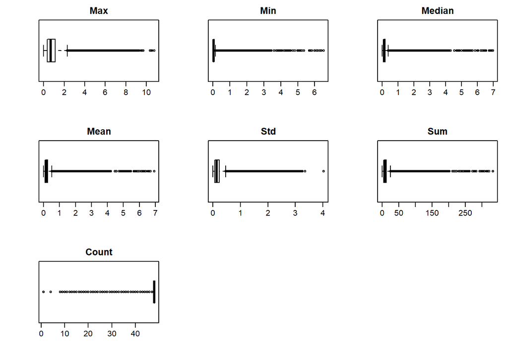

```r
#par(mfrow=c(2,1)) #Dividim finestra en 2 files i 1 columna
library(sfsmisc)

mult.fig(7)

boxplot(daily_dataset_csv$energy_max, main="Max",horizontal = TRUE)
boxplot(daily_dataset_csv$energy_min, main="Min",horizontal = TRUE)

boxplot(daily_dataset_csv$energy_median, main="Median",horizontal = TRUE)
boxplot(daily_dataset_csv$energy_mean, main="Mean",horizontal = TRUE)

boxplot(daily_dataset_csv$energy_std, main="Std",horizontal = TRUE)
boxplot(daily_dataset_csv$energy_sum, main="Sum",horizontal = TRUE)

boxplot(daily_dataset_csv$energy_count, main="Count",horizontal = TRUE)
```

Veiem que es consideren molts outliers, tot i que no sembla haver-hi cap valor atípic. Sí que podem veure que per exemple a energy_max hi ha alguns valors que superen 10 que estan més separats dels altres valors, i igual veiem amb count i std.

```r
#Ordenem les dades per data
daily_dataset_csv<-daily_dataset_csv[order(daily_dataset_csv$day),]
```

Gràfics

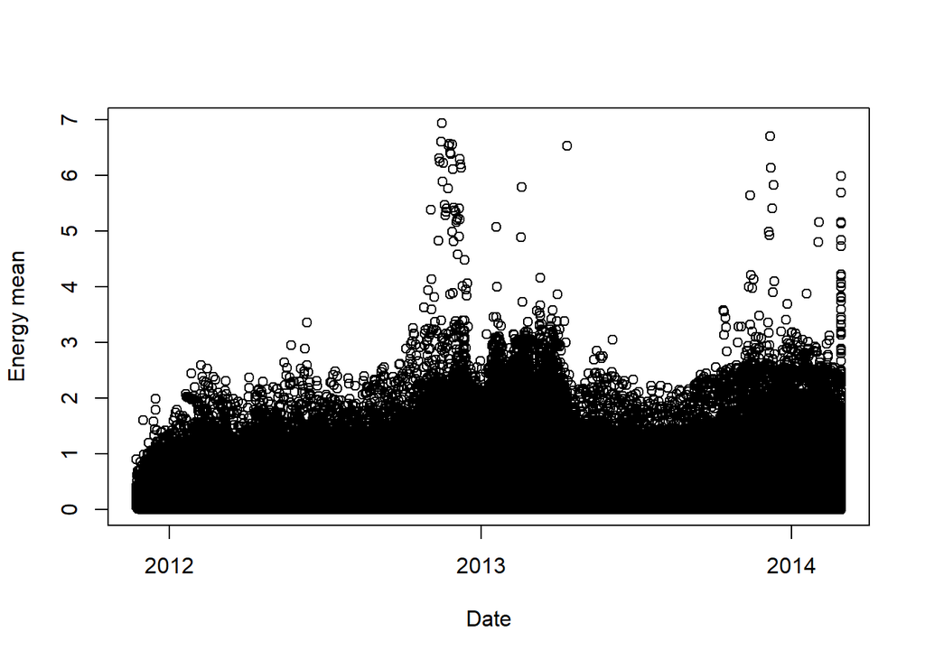

```r
plot(daily_dataset_csv$day, daily_dataset_csv$energy_mean , ylab="Energy mean", xlab="Date")
```

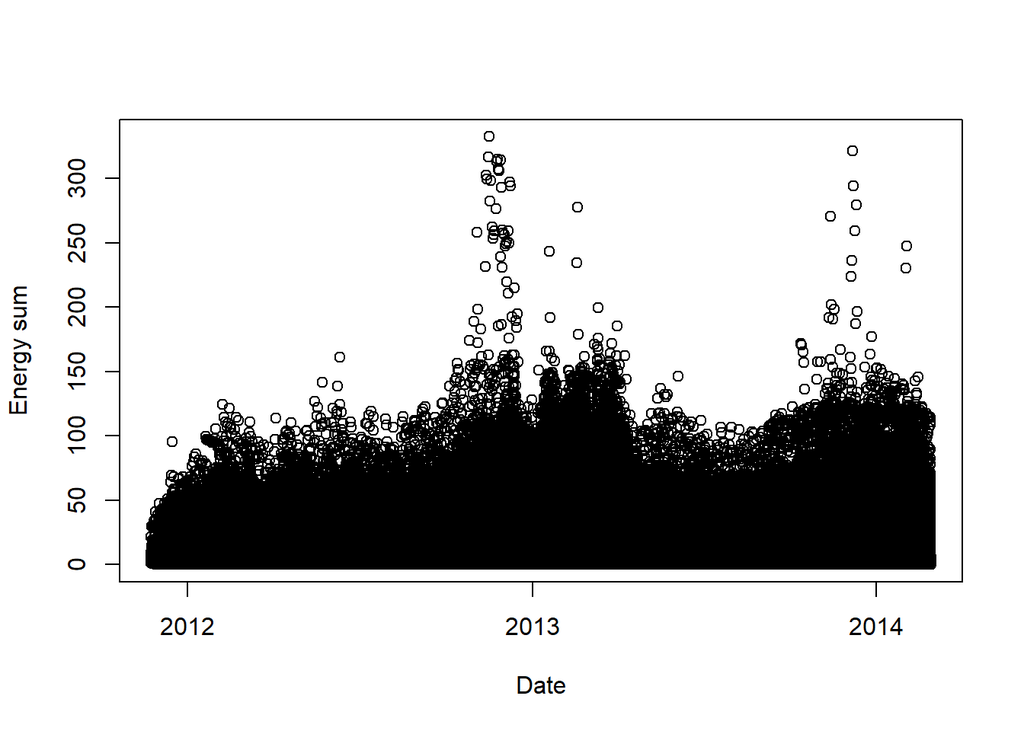

```r
plot(daily_dataset_csv$day, daily_dataset_csv$energy_sum , ylab="Energy sum", xlab="Date")
```

# Daily_dataset (blocs)

```r
library(timereg)
library(mets)
library(data.table)
library(timeDate)
#Creem una llista amb els noms dels arxius que volem carregar que es troben a la carpeta indicada

files<-list.files(path="dades/3daily_dataset")

#Creem dataframe amb les dades de tots els blocs,
daily_dataset <- do.call(rbind, lapply(files, function(x) as.data.frame(fread(x,header = TRUE))))
head(daily_dataset)
```

```
##       LCLid        day energy_median energy_mean energy_max energy_count
## 1 MAC000002 2012-10-12        0.1385   0.1543043      0.886           46
## 2 MAC000002 2012-10-13        0.1800   0.2309792      0.933           48
## 3 MAC000002 2012-10-14        0.1580   0.2754792      1.085           48
## 4 MAC000002 2012-10-15        0.1310   0.2136875      1.164           48
## 5 MAC000002 2012-10-16        0.1450   0.2035208      0.991           48
## 6 MAC000002 2012-10-17        0.1480   0.2267708      0.784           48
##   energy_std energy_sum energy_min
## 1  0.1960339      7.098      0.000
## 2  0.1923290     11.087      0.076
## 3  0.2746472     13.223      0.070
## 4  0.2244834     10.257      0.070
## 5  0.1841152      9.769      0.087
## 6  0.1844086     10.885      0.067
```

```r
#Resum dades

#Dimensio
dim(daily_dataset)
```

```
## [1] 3510433       9
```

```r
# Resum
summary(daily_dataset)
```

```
##     LCLid               day            energy_median     energy_mean
##  Length:3510433     Length:3510433     Min.   :0.0000   Min.   :0.00000
##  Class :character   Class :character   1st Qu.:0.0670   1st Qu.:0.09808
##  Mode  :character   Mode  :character   Median :0.1145   Median :0.16329
##                                        Mean   :0.1587   Mean   :0.21173
##                                        3rd Qu.:0.1910   3rd Qu.:0.26246
##                                        Max.   :6.9705   Max.   :6.92825
##                                        NA's   :30       NA's   :30
##    energy_max       energy_count    energy_std      energy_sum
##  Min.   : 0.0000   Min.   : 0.0   Min.   :0.000   Min.   :  0.000
##  1st Qu.: 0.3460   1st Qu.:48.0   1st Qu.:0.069   1st Qu.:  4.682
##  Median : 0.6880   Median :48.0   Median :0.133   Median :  7.815
##  Mean   : 0.8345   Mean   :47.8   Mean   :0.173   Mean   : 10.124
##  3rd Qu.: 1.1280   3rd Qu.:48.0   3rd Qu.:0.229   3rd Qu.: 12.569
##  Max.   :10.7610   Max.   :48.0   Max.   :4.025   Max.   :332.556
##  NA's   :30                       NA's   :11331   NA's   :30
##    energy_min
##  Min.   :0.00000
##  1st Qu.:0.02000
##  Median :0.03900
##  Mean   :0.05963
##  3rd Qu.:0.07100
##  Max.   :6.52400
##  NA's   :30
```

```r
# Tipus de dades
str(daily_dataset)
```

```
## 'data.frame':    3510433 obs. of  9 variables:
##  $ LCLid        : chr  "MAC000002" "MAC000002" "MAC000002" "MAC000002" ...
##  $ day          : chr  "2012-10-12" "2012-10-13" "2012-10-14" "2012-10-15" ...
##  $ energy_median: num  0.139 0.18 0.158 0.131 0.145 ...
##  $ energy_mean  : num  0.154 0.231 0.275 0.214 0.204 ...
##  $ energy_max   : num  0.886 0.933 1.085 1.164 0.991 ...
##  $ energy_count : int  46 48 48 48 48 48 48 48 48 48 ...
##  $ energy_std   : num  0.196 0.192 0.275 0.224 0.184 ...
##  $ energy_sum   : num  7.1 11.09 13.22 10.26 9.77 ...
##  $ energy_min   : num  0 0.076 0.07 0.07 0.087 0.067 0.102 0.072 0.073 0.232 ...
```

Veiem que són els mateixos valors que daily_dataset_csv, per tant, com que ja hem tractat el primer fitxer, doncs obviarem daily_dataset.

# Fem dataset total daily:

## Daily

Posem dades de informations households, weather daily, uk bank holidays i daily

Seleccionem dades que volem de weather

```r
library(dplyr)
weather_d<-select(weather_daily, temperatureMax, temperatureMaxHour,temperatureMin, temperatureMinHour, apparentTemperatureMax, apparentTemperatureMaxHour, apparentTemperatureMin, apparentTemperatureMinHour, temperatureHigh, temperatureHighHour, temperatureLow, temperatureLowHour, apparentTemperatureHigh, apparentTemperatureHighHour, apparentTemperatureLow, apparentTemperatureLowHour,windBearing, dewPoint, cloudCover, windSpeed, pressure, humidity, visibility, moonPhase, icon, precipType, summary, uvIndex, uvIndexHour, sunsetTimeHour,sunriseTimeHour ,date,year, month, weekday)
```

```r
str(weather_d)
```

```
## 'data.frame':    882 obs. of  35 variables:
##  $ temperatureMax             : num  15.6 15.2 17.4 15.5 13.9 ...
##  $ temperatureMaxHour         : int  15 23 14 11 15 14 13 0 13 15 ...
##  $ temperatureMin             : num  9.68 8.88 12.79 11.53 10.17 ...
##  $ temperatureMinHour         : int  22 3 21 23 2 5 0 9 0 4 ...
##  $ apparentTemperatureMax     : num  15.6 15.2 17.4 15.5 13.9 ...
##  $ apparentTemperatureMaxHour : int  15 23 14 11 15 14 13 0 13 15 ...
##  $ apparentTemperatureMin     : num  9.01 7.33 12.79 11.53 10.17 ...
##  $ apparentTemperatureMinHour : int  22 3 21 23 2 6 0 8 0 4 ...
##  $ temperatureHigh            : num  15.6 15.1 17.4 15.5 13.9 ...
##  $ temperatureHighHour        : int  15 13 14 11 15 14 13 16 13 15 ...
##  $ temperatureLow             : num  8.88 13.99 12.52 10.17 9.46 ...
##  $ temperatureLowHour         : int  3 19 7 2 5 0 8 21 4 7 ...
##  $ apparentTemperatureHigh    : num  15.6 15.1 17.4 15.5 13.9 ...
##  $ apparentTemperatureHighHour: int  15 13 14 11 15 14 13 16 13 15 ...
```

[output cut: 21 more lines]

```r
str(daily_dataset_csv)
```

```
## 'data.frame':    3510403 obs. of  9 variables:
##  $ LCLid        : chr  "MAC000152" "MAC000153" "MAC000156" "MAC000147" ...
##  $ day          : Date, format: "2011-11-23" "2011-11-23" ...
##  $ energy_median: num  0.172 0.676 0.275 0.075 0.174 ...
##  $ energy_mean  : num  0.249 0.904 0.297 0.108 0.252 ...
##  $ energy_max   : num  0.798 2.407 0.512 0.315 0.999 ...
##  $ energy_count : int  24 24 22 28 23 30 28 28 22 28 ...
##  $ energy_std   : num  0.194 0.5923 0.108 0.0717 0.2192 ...
##  $ energy_sum   : num  5.97 21.7 6.52 3.04 5.8 ...
##  $ energy_min   : num  0.055 0.261 0.162 0.033 0.098 0.094 0.008 0 0.11 0.059 ...
```

```r
#Ajuntem datasets daily_dataset i uk_bank_holidays a partir del dia
daily<-left_join(daily_dataset_csv, uk_bank_holidays)
str(daily)
```

```
## 'data.frame':    3510403 obs. of  10 variables:
##  $ LCLid        : chr  "MAC000152" "MAC000153" "MAC000156" "MAC000147" ...
##  $ day          : Date, format: "2011-11-23" "2011-11-23" ...
##  $ energy_median: num  0.172 0.676 0.275 0.075 0.174 ...
##  $ energy_mean  : num  0.249 0.904 0.297 0.108 0.252 ...
##  $ energy_max   : num  0.798 2.407 0.512 0.315 0.999 ...
##  $ energy_count : int  24 24 22 28 23 30 28 28 22 28 ...
##  $ energy_std   : num  0.194 0.5923 0.108 0.0717 0.2192 ...
##  $ energy_sum   : num  5.97 21.7 6.52 3.04 5.8 ...
##  $ energy_min   : num  0.055 0.261 0.162 0.033 0.098 0.094 0.008 0 0.11 0.059 ...
##  $ holidayType  : Factor w/ 9 levels "Boxing Day","Christmas Day",..: NA NA NA NA NA NA NA NA NA NA ...
```

```r
#Com que els dies que no s?n vacances els marca com NA, els convertim en un factor m?s "No Holiday"
daily$holidayType<-as.character(daily$holidayType)
daily$holidayType[is.na(daily$holidayType)]="No Holiday"
daily$holidayType<-as.factor(daily$holidayType)
```

```r
str(daily)
```

```
## 'data.frame':    3510403 obs. of  10 variables:
##  $ LCLid        : chr  "MAC000152" "MAC000153" "MAC000156" "MAC000147" ...
##  $ day          : Date, format: "2011-11-23" "2011-11-23" ...
##  $ energy_median: num  0.172 0.676 0.275 0.075 0.174 ...
##  $ energy_mean  : num  0.249 0.904 0.297 0.108 0.252 ...
##  $ energy_max   : num  0.798 2.407 0.512 0.315 0.999 ...
##  $ energy_count : int  24 24 22 28 23 30 28 28 22 28 ...
##  $ energy_std   : num  0.194 0.5923 0.108 0.0717 0.2192 ...
##  $ energy_sum   : num  5.97 21.7 6.52 3.04 5.8 ...
##  $ energy_min   : num  0.055 0.261 0.162 0.033 0.098 0.094 0.008 0 0.11 0.059 ...
##  $ holidayType  : Factor w/ 10 levels "Boxing Day","Christmas Day",..: 7 7 7 7 7 7 7 7 7 7 ...
```

```r
#Afegim variable isHoliday que indica si es un dia de vacances o no

daily$isHoliday[daily$holidayType == "No Holiday"]<-FALSE
daily$isHoliday[daily$holidayType != "No Holiday"]<-TRUE
```

```r
#Seleccionem atributs que volem de informations_households
informations_households_atributs<-select(informations_households, LCLid, stdorToU, Acorn, Acorn_grouped)
```

```r
#Ajuntem daily (daily_dataset i uk_holiday) amb information_households
daily<-left_join(daily, informations_households_atributs)
str(daily)
```

```
## 'data.frame':    3510403 obs. of  14 variables:
##  $ LCLid        : chr  "MAC000152" "MAC000153" "MAC000156" "MAC000147" ...
##  $ day          : Date, format: "2011-11-23" "2011-11-23" ...
##  $ energy_median: num  0.172 0.676 0.275 0.075 0.174 ...
##  $ energy_mean  : num  0.249 0.904 0.297 0.108 0.252 ...
##  $ energy_max   : num  0.798 2.407 0.512 0.315 0.999 ...
##  $ energy_count : int  24 24 22 28 23 30 28 28 22 28 ...
##  $ energy_std   : num  0.194 0.5923 0.108 0.0717 0.2192 ...
##  $ energy_sum   : num  5.97 21.7 6.52 3.04 5.8 ...
##  $ energy_min   : num  0.055 0.261 0.162 0.033 0.098 0.094 0.008 0 0.11 0.059 ...
##  $ holidayType  : Factor w/ 10 levels "Boxing Day","Christmas Day",..: 7 7 7 7 7 7 7 7 7 7 ...
##  $ isHoliday    : logi  FALSE FALSE FALSE FALSE FALSE FALSE ...
##  $ stdorToU     : Factor w/ 2 levels "Std","ToU": 1 1 1 2 1 1 1 1 1 1 ...
##  $ Acorn        : Factor w/ 19 levels "ACORN-","ACORN-A",..: 6 6 7 7 18 7 7 7 5 6 ...
##  $ Acorn_grouped: Factor w/ 5 levels "ACORN-","ACORN-U",..: 4 4 5 5 3 5 5 5 4 4 ...
```

```r
#Renombrem columnes perqu? en els dos datasets la data es digui date
colnames(daily)[colnames(daily)=="day"]<-"date"
```

```r
#Ajuntem daily amb weather_d(weather_daily amb els atributs que volem) per data

daily<-left_join(daily, weather_d)
str(daily)
```

```
## 'data.frame':    3517002 obs. of  48 variables:
##  $ LCLid                      : chr  "MAC000152" "MAC000153" "MAC000156" "MAC000147" ...
##  $ date                       : Date, format: "2011-11-23" "2011-11-23" ...
##  $ energy_median              : num  0.172 0.676 0.275 0.075 0.174 ...
##  $ energy_mean                : num  0.249 0.904 0.297 0.108 0.252 ...
##  $ energy_max                 : num  0.798 2.407 0.512 0.315 0.999 ...
##  $ energy_count               : int  24 24 22 28 23 30 28 28 22 28 ...
##  $ energy_std                 : num  0.194 0.5923 0.108 0.0717 0.2192 ...
##  $ energy_sum                 : num  5.97 21.7 6.52 3.04 5.8 ...
##  $ energy_min                 : num  0.055 0.261 0.162 0.033 0.098 0.094 0.008 0 0.11 0.059 ...
##  $ holidayType                : Factor w/ 10 levels "Boxing Day","Christmas Day",..: 7 7 7 7 7 7 7 7 7 7 ...
##  $ isHoliday                  : logi  FALSE FALSE FALSE FALSE FALSE FALSE ...
##  $ stdorToU                   : Factor w/ 2 levels "Std","ToU": 1 1 1 2 1 1 1 1 1 1 ...
##  $ Acorn                      : Factor w/ 19 levels "ACORN-","ACORN-A",..: 6 6 7 7 18 7 7 7 5 6 ...
##  $ Acorn_grouped              : Factor w/ 5 levels "ACORN-","ACORN-U",..: 4 4 5 5 3 5 5 5 4 4 ...
```

[output cut: 34 more lines]

```r
summary(daily)
```

```
##     LCLid                date            energy_median
##  Length:3517002     Min.   :2011-11-23   Min.   :0.0000
##  Class :character   1st Qu.:2012-10-21   1st Qu.:0.0670
##  Mode  :character   Median :2013-03-30   Median :0.1145
##                     Mean   :2013-03-27   Mean   :0.1588
##                     3rd Qu.:2013-09-10   3rd Qu.:0.1915
##                     Max.   :2014-02-28   Max.   :6.9705
##
##   energy_mean        energy_max       energy_count    energy_std
##  Min.   :0.00000   Min.   : 0.0000   Min.   : 1.0   Min.   :0.000
##  1st Qu.:0.09808   1st Qu.: 0.3450   1st Qu.:48.0   1st Qu.:0.069
##  Median :0.16331   Median : 0.6880   Median :48.0   Median :0.133
##  Mean   :0.21179   Mean   : 0.8347   Mean   :47.8   Mean   :0.173
##  3rd Qu.:0.26254   3rd Qu.: 1.1290   3rd Qu.:48.0   3rd Qu.:0.229
##  Max.   :6.92825   Max.   :10.7610   Max.   :48.0   Max.   :4.025
##                                                     NA's   :11309
##    energy_sum        energy_min                   holidayType
##  Min.   :  0.000   Min.   :0.00000   No Holiday         :3436372
##  1st Qu.:  4.682   1st Qu.:0.02000   New Years Day      :  11202
##  Median :  7.816   Median :0.03900   Christmas Day      :  10618
##  Mean   : 10.127   Mean   :0.05964   Boxing Day         :  10616
##  3rd Qu.: 12.572   3rd Qu.:0.07100   Easter Monday      :  10276
##  Max.   :332.556   Max.   :6.52400   Summer bank holiday:  10011
##                                      (Other)            :  27907
##  isHoliday       stdorToU          Acorn             Acorn_grouped
##  Mode :logical   Std:2809679   ACORN-E:1024498   ACORN-     :      0
##  FALSE:3436372   ToU: 707323   ACORN-Q: 534073   ACORN-U    :      0
##  TRUE :80630                   ACORN-F: 448035   Adversity  :1166999
##                                ACORN-H: 272360   Affluent   :1411215
##                                ACORN-L: 204338   Comfortable: 938788
##                                ACORN-D: 189338
##                                (Other): 844360
##  temperatureMax  temperatureMaxHour temperatureMin   temperatureMinHour
##  Min.   :-0.06   Min.   : 0.00      Min.   :-5.640   Min.   : 0.000
##  1st Qu.: 9.42   1st Qu.:13.00      1st Qu.: 3.680   1st Qu.: 4.000
##  Median :13.21   Median :14.00      Median : 7.600   Median : 5.000
##  Mean   :14.13   Mean   :13.73      Mean   : 7.866   Mean   : 9.043
##  3rd Qu.:18.82   3rd Qu.:16.00      3rd Qu.:12.070   3rd Qu.:15.000
##  Max.   :32.40   Max.   :23.00      Max.   :20.540   Max.   :23.000
##  NA's   :10714   NA's   :10714      NA's   :10714    NA's   :10714
```

[output cut: 65 more lines]

```
##  Min.   : 0.0    Min.   :15.00   Min.   :3.000   Min.   :2011
##  1st Qu.:10.0    1st Qu.:16.00   1st Qu.:4.000   1st Qu.:2012
##  Median :11.0    Median :17.00   Median :6.000   Median :2013
##  Mean   :10.6    Mean   :17.56   Mean   :5.494   Mean   :2013
##  3rd Qu.:12.0    3rd Qu.:19.00   3rd Qu.:7.000   3rd Qu.:2013
##  Max.   :13.0    Max.   :20.00   Max.   :8.000   Max.   :2014
##  NA's   :10714   NA's   :10714   NA's   :10714   NA's   :10714
##      month           weekday
##  Min.   : 1.000   Min.   :1.000
##  1st Qu.: 4.000   1st Qu.:2.000
##  Median : 7.000   Median :4.000
##  Mean   : 6.702   Mean   :3.995
##  3rd Qu.:10.000   3rd Qu.:6.000
##  Max.   :12.000   Max.   :7.000
##  NA's   :10714    NA's   :10714
```

```r
daily_copia<- daily
```

```r
#carreguem estacio(season)

season_arxiu<-read.csv(file="dades/season.csv", header=TRUE, sep=";")
```

```r
#Passem variable date a Date
season_arxiu$date<-as.Date(season_arxiu$date)
```

```r
#Afegim variable estacio a daily


daily<-left_join(daily, season_arxiu)
str(daily)
```

```
## 'data.frame':    3517002 obs. of  49 variables:
##  $ LCLid                      : chr  "MAC000152" "MAC000153" "MAC000156" "MAC000147" ...
##  $ date                       : Date, format: "2011-11-23" "2011-11-23" ...
##  $ energy_median              : num  0.172 0.676 0.275 0.075 0.174 ...
##  $ energy_mean                : num  0.249 0.904 0.297 0.108 0.252 ...
##  $ energy_max                 : num  0.798 2.407 0.512 0.315 0.999 ...
##  $ energy_count               : int  24 24 22 28 23 30 28 28 22 28 ...
##  $ energy_std                 : num  0.194 0.5923 0.108 0.0717 0.2192 ...
##  $ energy_sum                 : num  5.97 21.7 6.52 3.04 5.8 ...
##  $ energy_min                 : num  0.055 0.261 0.162 0.033 0.098 0.094 0.008 0 0.11 0.059 ...
##  $ holidayType                : Factor w/ 10 levels "Boxing Day","Christmas Day",..: 7 7 7 7 7 7 7 7 7 7 ...
##  $ isHoliday                  : logi  FALSE FALSE FALSE FALSE FALSE FALSE ...
##  $ stdorToU                   : Factor w/ 2 levels "Std","ToU": 1 1 1 2 1 1 1 1 1 1 ...
##  $ Acorn                      : Factor w/ 19 levels "ACORN-","ACORN-A",..: 6 6 7 7 18 7 7 7 5 6 ...
##  $ Acorn_grouped              : Factor w/ 5 levels "ACORN-","ACORN-U",..: 4 4 5 5 3 5 5 5 4 4 ...
```

[output cut: 35 more lines]

```r
colSums(is.na(daily))
```

```
##                       LCLid                        date
##                           0                           0
##               energy_median                 energy_mean
##                           0                           0
##                  energy_max                energy_count
##                           0                           0
##                  energy_std                  energy_sum
##                       11309                           0
##                  energy_min                 holidayType
##                           0                           0
##                   isHoliday                    stdorToU
##                           0                           0
##                       Acorn               Acorn_grouped
##                           0                           0
##              temperatureMax          temperatureMaxHour
##                       10714                       10714
##              temperatureMin          temperatureMinHour
##                       10714                       10714
##      apparentTemperatureMax  apparentTemperatureMaxHour
##                       10714                       10714
##      apparentTemperatureMin  apparentTemperatureMinHour
##                       10714                       10714
##             temperatureHigh         temperatureHighHour
##                       10714                       10714
##              temperatureLow          temperatureLowHour
##                       10714                       10714
##     apparentTemperatureHigh apparentTemperatureHighHour
##                       10714                       10714
##      apparentTemperatureLow  apparentTemperatureLowHour
##                       10714                       10714
##                 windBearing                    dewPoint
##                       10714                       10714
##                  cloudCover                   windSpeed
##                       10714                       10714
##                    pressure                    humidity
##                       10714                       10714
##                  visibility                   moonPhase
##                       10714                       10714
##                        icon                  precipType
##                       10714                       10714
##                     summary                     uvIndex
##                       10714                       10714
##                 uvIndexHour              sunsetTimeHour
##                       10714                       10714
##             sunriseTimeHour                        year
##                       10714                       10714
##                       month                     weekday
##                       10714                       10714
##                      season
##                           0
```

```r
#Solucionem valors buits year, month i weekday

daily$year<-year(daily$date)
daily$month<-month(daily$date)
daily$weekday<-wday(daily$date)#Week_start=-1 means Monday.  7 means sunday.
```

```r
colSums(is.na(daily))
```

```
##                       LCLid                        date
##                           0                           0
##               energy_median                 energy_mean
##                           0                           0
##                  energy_max                energy_count
##                           0                           0
##                  energy_std                  energy_sum
##                       11309                           0
##                  energy_min                 holidayType
##                           0                           0
##                   isHoliday                    stdorToU
##                           0                           0
##                       Acorn               Acorn_grouped
##                           0                           0
##              temperatureMax          temperatureMaxHour
##                       10714                       10714
##              temperatureMin          temperatureMinHour
##                       10714                       10714
##      apparentTemperatureMax  apparentTemperatureMaxHour
##                       10714                       10714
##      apparentTemperatureMin  apparentTemperatureMinHour
##                       10714                       10714
##             temperatureHigh         temperatureHighHour
##                       10714                       10714
##              temperatureLow          temperatureLowHour
##                       10714                       10714
##     apparentTemperatureHigh apparentTemperatureHighHour
##                       10714                       10714
##      apparentTemperatureLow  apparentTemperatureLowHour
##                       10714                       10714
##                 windBearing                    dewPoint
##                       10714                       10714
##                  cloudCover                   windSpeed
##                       10714                       10714
##                    pressure                    humidity
##                       10714                       10714
##                  visibility                   moonPhase
##                       10714                       10714
##                        icon                  precipType
##                       10714                       10714
##                     summary                     uvIndex
##                       10714                       10714
##                 uvIndexHour              sunsetTimeHour
##                       10714                       10714
##             sunriseTimeHour                        year
##                       10714                           0
##                       month                     weekday
##                           0                           0
##                      season
##                           0
```

```r
#Eliminem energy_std

daily<-select(daily, -energy_std)
```

```r
daily[is.na(daily$uvIndexHour),]
```

```
##             LCLid       date energy_median  energy_mean energy_max
## 914157  MAC000131 2012-10-28        0.0665 1.611458e-01      0.737
## 914158  MAC000132 2012-10-28        0.3515 4.369792e-01      1.517
## 914159  MAC000221 2012-10-28        0.1230 2.606250e-01      1.422
## 914160  MAC000228 2012-10-28        0.1890 2.006875e-01      1.016
## 914161  MAC000234 2012-10-28        0.2225 2.311458e-01      0.783
## 914162  MAC000235 2012-10-28        0.0330 3.095833e-02      0.057
## 914163  MAC003506 2012-10-28        0.1105 1.520625e-01      0.350
## 914164  MAC004356 2012-10-28        0.1895 2.627083e-01      1.196
## 914165  MAC004538 2012-10-28        0.0735 1.100208e-01      0.350
## 914166  MAC004548 2012-10-28        0.1275 3.712917e-01      1.686
## 914167  MAC004549 2012-10-28        0.0180 1.766667e-02      0.018
## 914168  MAC004552 2012-10-28        0.0375 3.772917e-02      0.050
## 914169  MAC004553 2012-10-28        0.1355 2.638958e-01      1.733
## 914170  MAC004555 2012-10-28        0.0665 6.481250e-02      0.094
```

[output cut: 490 more lines]

Tots els valors buits que hi ha (que eren del fitxer weather_daily), corresponen al mateix dia, 28-10-2012

Extraiem els valors que podem de weather_hourly

```r
weather_hourly <-read.csv(file="C:/Users/Laura/Desktop/Smart meters London/workspace R/Dades netes/weather_hourly.csv", header=TRUE, sep=",")
str(weather_hourly)
```

```
## 'data.frame':    21165 obs. of  18 variables:
##  $ X                  : int  313 314 315 316 317 318 319 320 321 322 ...
##  $ visibility         : num  13.6 13.3 12.9 13 12.9 ...
##  $ windBearing        : int  160 154 161 170 180 187 224 245 242 247 ...
##  $ temperature        : num  13.5 12.7 13.6 14.1 14.2 ...
##  $ time               : Factor w/ 21165 levels "2011-11-01 00:00:00",..: 1 2 3 4 5 6 7 8 9 10 ...
##  $ dewPoint           : num  11.5 11.6 12.1 12.2 12.6 ...
##  $ pressure           : num  1008 1008 1007 1006 1006 ...
##  $ apparentTemperature: num  13.5 12.7 13.6 14.1 14.2 ...
##  $ windSpeed          : num  3.11 3.08 3.71 3.95 3.97 3.76 2.53 2.49 1.66 3.17 ...
##  $ precipType         : Factor w/ 2 levels "rain","snow": 1 1 1 1 1 1 1 1 1 1 ...
##  $ icon               : Factor w/ 7 levels "clear-day","clear-night",..: 2 6 2 6 6 6 6 5 5 5 ...
##  $ humidity           : num  0.88 0.93 0.91 0.88 0.9 0.9 0.92 0.88 0.88 0.9 ...
##  $ summary            : Factor w/ 13 levels "Breezy","Breezy and Mostly Cloudy",..: 5 9 5 9 9 9 7 7 9 7 ...
##  $ hour               : int  0 1 2 3 4 5 6 7 8 9 ...
##  $ date               : Factor w/ 882 levels "2011-11-01","2011-11-02",..: 1 1 1 1 1 1 1 1 1 1 ...
##  $ year               : int  2011 2011 2011 2011 2011 2011 2011 2011 2011 2011 ...
##  $ month              : int  11 11 11 11 11 11 11 11 11 11 ...
##  $ weekday            : int  2 2 2 2 2 2 2 2 2 2 ...
```

```r
weather_hourly[weather_hourly$date=="2012-10-28", ]
```

```
##         X visibility windBearing temperature                time dewPoint
## 8689 5474      12.87         312        3.76 2012-10-28 00:00:00     1.34
## 8690 5475      12.73         279        2.85 2012-10-28 01:00:00     1.26
## 8691 5476      13.45         262        1.99 2012-10-28 02:00:00     0.77
## 8692 5477      12.47         256        1.79 2012-10-28 03:00:00     0.60
## 8693 5478      12.31         250        1.43 2012-10-28 04:00:00     0.64
## 8694 5479      13.08         246        1.87 2012-10-28 05:00:00     0.73
## 8695 5480      12.87         224        2.06 2012-10-28 06:00:00     0.80
## 8696 5481      13.74         231        2.64 2012-10-28 07:00:00     1.02
## 8697 5482      13.12         225        3.00 2012-10-28 08:00:00     1.29
## 8698 5483      13.07         223        5.03 2012-10-28 09:00:00     2.32
## 8699 5484      13.07         222        6.45 2012-10-28 10:00:00     3.31
## 8700 5485      13.07         225        7.01 2012-10-28 11:00:00     3.97
## 8701 5486      13.07         227        7.19 2012-10-28 12:00:00     4.67
## 8702 5487      13.07         230        8.22 2012-10-28 13:00:00     5.62
```

[output cut: 60 more lines]

```r
daily$temperatureMax[is.na(daily$uvIndexHour)]<- 9.17
daily$temperatureMin[is.na(daily$uvIndexHour)]<- 1.43


daily$temperatureMaxHour[is.na(daily$uvIndexHour)]<- 15
daily$temperatureMinHour[is.na(daily$uvIndexHour)]<- 4

daily$visibility[is.na(daily$uvIndexHour)]<- mean(  weather_hourly$visibility[weather_hourly$date=="2012-10-28" ]  )
daily$windBearing[is.na(daily$uvIndexHour)]<- mean(  weather_hourly$windBearing[weather_hourly$date=="2012-10-28" ]  )


daily$dewPoint[is.na(daily$uvIndexHour)]<- mean(  weather_hourly$dewPoint[weather_hourly$date=="2012-10-28" ]  )
daily$pressure[is.na(daily$uvIndexHour)]<-mean(  weather_hourly$pressure[weather_hourly$date=="2012-10-28" ]  )

daily$apparentTemperatureMax[is.na(daily$uvIndexHour)]<- 6.89
daily$apparentTemperatureMin[is.na(daily$uvIndexHour)]<- (-0.94)
daily$apparentTemperatureMaxHour[is.na(daily$uvIndexHour)]<-17
daily$apparentTemperatureMinHour[is.na(daily$uvIndexHour)]<-4

daily$windSpeed[is.na(daily$uvIndexHour)]<- mean(  weather_hourly$windSpeed[weather_hourly$date=="2012-10-28" ]  )
daily$precipType[is.na(daily$uvIndexHour)]<- "rain"
daily$icon[is.na(daily$uvIndexHour)]<- "partly-cloudy-day"
daily$humidity[is.na(daily$uvIndexHour)]<- mean(  weather_hourly$humidity[weather_hourly$date=="2012-10-28" ]  )
daily$summary[is.na(daily$uvIndexHour)]<-"Partly cloudy throughout the day."
```

```r
#Comprovem quins són els vaors que ara ens queden buits:
colSums(is.na(daily))
```

```
##                       LCLid                        date
##                           0                           0
##               energy_median                 energy_mean
##                           0                           0
##                  energy_max                energy_count
##                           0                           0
##                  energy_sum                  energy_min
##                           0                           0
##                 holidayType                   isHoliday
##                           0                           0
##                    stdorToU                       Acorn
##                           0                           0
##               Acorn_grouped              temperatureMax
##                           0                           0
##          temperatureMaxHour              temperatureMin
##                           0                           0
##          temperatureMinHour      apparentTemperatureMax
##                           0                           0
##  apparentTemperatureMaxHour      apparentTemperatureMin
##                           0                           0
##  apparentTemperatureMinHour             temperatureHigh
##                           0                       10714
##         temperatureHighHour              temperatureLow
##                       10714                       10714
##          temperatureLowHour     apparentTemperatureHigh
##                       10714                       10714
## apparentTemperatureHighHour      apparentTemperatureLow
##                       10714                       10714
##  apparentTemperatureLowHour                 windBearing
##                       10714                           0
##                    dewPoint                  cloudCover
##                           0                       10714
##                   windSpeed                    pressure
##                           0                           0
##                    humidity                  visibility
##                           0                           0
##                   moonPhase                        icon
##                       10714                           0
##                  precipType                     summary
##                           0                           0
##                     uvIndex                 uvIndexHour
##                       10714                       10714
##              sunsetTimeHour             sunriseTimeHour
##                       10714                       10714
##                        year                       month
##                           0                           0
##                     weekday                      season
##                           0                           0
```

Veiem que ens falta temp. High i Low i les hore i apparent_temp highi low i les hores. També cloudcover, moonphase, uvindex i uvindexhour, sunset i sunrise.

Per les temperatures, per a high agafarem les temperatures de Max i per a low agafarem les temperatures de min.

```r
daily$temperatureHigh[is.na(daily$uvIndexHour)]<- 9.17
daily$temperatureLow[is.na(daily$uvIndexHour)]<- 1.43

daily$temperatureHighHour[is.na(daily$uvIndexHour)]<- 15
daily$temperatureLowHour[is.na(daily$uvIndexHour)]<- 4

daily$apparentTemperatureHigh[is.na(daily$uvIndexHour)]<- 6.89
daily$apparentTemperatureLow[is.na(daily$uvIndexHour)]<- (-0.94)
daily$apparentTemperatureHighHour[is.na(daily$uvIndexHour)]<-17
daily$apparentTemperatureLowHour[is.na(daily$uvIndexHour)]<-4
```

Per cloudcover buscuqem quin valor tenen els dies amb icon partlycloudy, pels altres fem la mitjana del dia anterior amb el seguent.

```r
weather_daily[weather_daily$date=="2012-10-29", ]
```

```
##     temperatureMax windBearing              icon dewPoint cloudCover
## 295           12.4         238 partly-cloudy-day     7.73       0.45
##     windSpeed pressure apparentTemperatureHigh precipType visibility
## 295      2.95  1008.71                    12.4       rain      12.49
##     humidity apparentTemperatureLow apparentTemperatureMax uvIndex
## 295     0.89                   3.44                   12.4       1
##     temperatureLow temperatureMin temperatureHigh
## 295           5.57           7.66            12.4
##                               summary apparentTemperatureMin moonPhase
## 295 Partly cloudy throughout the day.                   5.47      0.49
##     temperatureMaxHour       date temperatureMinHour
## 295                 12 2012-10-29                  1
##     apparentTemperatureMinHour apparentTemperatureMaxHour
## 295                          1                         12
##     apparentTemperatureHighHour apparentTemperatureLowHour sunsetTimeHour
## 295                          12                          8             16
##     sunriseTimeHour temperatureHighHour temperatureLowHour uvIndexHour
## 295               6                  12                  7           9
##     year month weekday
## 295 2012    10       1
```

```r
weather_daily[weather_daily$date=="2012-10-27", ]
```

```
##     temperatureMax windBearing              icon dewPoint cloudCover
## 229           9.17         234 partly-cloudy-day     3.96       0.42
##     windSpeed pressure apparentTemperatureHigh precipType visibility
## 229      3.13  1015.62                    6.89       rain      12.68
##     humidity apparentTemperatureLow apparentTemperatureMax uvIndex
## 229     0.88                   5.25                   6.89       1
##     temperatureLow temperatureMin temperatureHigh
## 229           7.66           1.43            9.17
##                               summary apparentTemperatureMin moonPhase
## 229 Partly cloudy throughout the day.                  -0.94      0.46
##     temperatureMaxHour       date temperatureMinHour
## 229                 15 2012-10-27                  4
##     apparentTemperatureMinHour apparentTemperatureMaxHour
## 229                          4                         17
##     apparentTemperatureHighHour apparentTemperatureLowHour sunsetTimeHour
## 229                          17                         22             16
##     sunriseTimeHour temperatureHighHour temperatureLowHour uvIndexHour
## 229               6                  15                  1           9
##     year month weekday
## 229 2012    10       6
```

```r
#Agafem els valors del dia abans o després:
daily$sunriseTimeHour[is.na(daily$uvIndexHour)]<- 6
daily$sunsetTimeHour[is.na(daily$uvIndexHour)]<-  16


daily$moonPhase[is.na(daily$uvIndexHour)]<- 0.48
daily$cloudCover[is.na(daily$uvIndexHour)]<- mean(weather_daily$cloudCover[weather_daily$summary=="Partly cloudy throughout the day." & weather_daily$icon=="partly-cloudy-day"])

daily$uvIndex[is.na(daily$uvIndexHour)]<- 1
daily$uvIndexHour[is.na(daily$uvIndexHour)]<- 9
```

Comprovem que no hi hagi valors buits:

```r
colSums(is.na(daily))
```

```
##                       LCLid                        date
##                           0                           0
##               energy_median                 energy_mean
##                           0                           0
##                  energy_max                energy_count
##                           0                           0
##                  energy_sum                  energy_min
##                           0                           0
##                 holidayType                   isHoliday
##                           0                           0
##                    stdorToU                       Acorn
##                           0                           0
##               Acorn_grouped              temperatureMax
##                           0                           0
##          temperatureMaxHour              temperatureMin
##                           0                           0
##          temperatureMinHour      apparentTemperatureMax
##                           0                           0
##  apparentTemperatureMaxHour      apparentTemperatureMin
##                           0                           0
##  apparentTemperatureMinHour             temperatureHigh
##                           0                           0
##         temperatureHighHour              temperatureLow
##                           0                           0
##          temperatureLowHour     apparentTemperatureHigh
##                           0                           0
## apparentTemperatureHighHour      apparentTemperatureLow
##                           0                           0
##  apparentTemperatureLowHour                 windBearing
##                           0                           0
##                    dewPoint                  cloudCover
##                           0                           0
##                   windSpeed                    pressure
##                           0                           0
##                    humidity                  visibility
##                           0                           0
##                   moonPhase                        icon
##                           0                           0
##                  precipType                     summary
##                           0                           0
##                     uvIndex                 uvIndexHour
##                           0                           0
##              sunsetTimeHour             sunriseTimeHour
##                           0                           0
##                        year                       month
##                           0                           0
##                     weekday                      season
##                           0                           0
```

```r
#Comprovem noms variables dataset daily
names(daily)
```

```
##  [1] "LCLid"                       "date"
##  [3] "energy_median"               "energy_mean"
##  [5] "energy_max"                  "energy_count"
##  [7] "energy_sum"                  "energy_min"
##  [9] "holidayType"                 "isHoliday"
## [11] "stdorToU"                    "Acorn"
## [13] "Acorn_grouped"               "temperatureMax"
## [15] "temperatureMaxHour"          "temperatureMin"
## [17] "temperatureMinHour"          "apparentTemperatureMax"
## [19] "apparentTemperatureMaxHour"  "apparentTemperatureMin"
## [21] "apparentTemperatureMinHour"  "temperatureHigh"
## [23] "temperatureHighHour"         "temperatureLow"
## [25] "temperatureLowHour"          "apparentTemperatureHigh"
## [27] "apparentTemperatureHighHour" "apparentTemperatureLow"
## [29] "apparentTemperatureLowHour"  "windBearing"
## [31] "dewPoint"                    "cloudCover"
## [33] "windSpeed"                   "pressure"
## [35] "humidity"                    "visibility"
## [37] "moonPhase"                   "icon"
## [39] "precipType"                  "summary"
## [41] "uvIndex"                     "uvIndexHour"
## [43] "sunsetTimeHour"              "sunriseTimeHour"
## [45] "year"                        "month"
## [47] "weekday"                     "season"
```

# Ens descarreguem (exportem) tots els arxius nets i el fitxer total.

```r
write.csv(informations_households, file="C:/Users/Laura/Desktop/Smart meters London/workspace R/Dades netes/informations_households.csv")
write.csv(weather_daily, file="C:/Users/Laura/Desktop/Smart meters London/workspace R/Dades netes/weather_daily.csv")
write.csv(uk_bank_holidays,file= "C:/Users/Laura/Desktop/Smart meters London/workspace R/Dades netes/uk_bank_holidays.csv" )
write.csv(daily_dataset_csv, file="C:/Users/Laura/Desktop/Smart meters London/workspace R/Dades netes/daily_dataset_csv.csv" )

#Dataset total
write.csv(daily,file="C:/Users/Laura/Desktop/Smart meters London/workspace R/Dades netes/daily.csv" )
```

# Altres

```r
#library(dplyr)
#daily_grouped_weekday<-daily[!is.na(daily$energy_mean)] %>% group_by(weekday)%>% summarise(avg=mean(energy_mean))
```

```r
#plot(daily_grouped_weekday)
```

```r
#plot(daily$weekday,daily$energy_mean)
```

```r
#library(C50)
#model_arbre_uvIndex<-C50::C5.0(X_train,y_train)
#model_arbre_uvIndex
```

```r
#Presentem al model creat les dades guardades per realitzar la predicció i mesurar la precisió de l'arbre
#predicted_model_arbre_uv <- predict( model_arbre_uvIndex, X_test, type="class" )
#print(sprintf("La precisió de l'arbre és: %.4f %%",100*sum(predicted_model_arbre_uv == y_test) / length(predicted_model_arbre_uv)))

#mat_conf_arbre_uv<-table(y_test,Predicted=predicted_model_arbre_uv)
#mat_conf_arbre_uv
```

```r
#Afegim variable isHoliday que indica si es un dia de vacances o no

#for (i in 1:(nrow(daily))){
#  if (daily$holidayType[i]== "No Holiday"){
#    daily$isHoliday[i]=FALSE
#  }else{
#   daily$isHoliday[i]=TRUE
#  }
#}
```